# Final Project - Homer Kay - Home Credit Default Risk

## Table of Contents:

### 1: Exploratory Data Analysis

### 2: Data Munging

### 3: Predictive Models

### 4: Competition Models & Submissions

Data & Competition: https://www.kaggle.com/c/home-credit-default-risk

```python
%matplotlib inline
import numpy as np
import matplotlib.pyplot as plt
import pandas as pd
#From Scikit Learn
from sklearn import preprocessing
from sklearn.model_selection  import train_test_split, cross_val_score, KFold
from sklearn.model_selection import GridSearchCV
from sklearn.metrics import accuracy_score, precision_score, recall_score, f1_score
from sklearn.metrics import roc_curve, auc, confusion_matrix, classification_report
from sklearn.metrics import roc_curve
from sklearn.metrics import roc_auc_score
from sklearn import metrics
```

```python
 # Checking Current Directory
%pwd
```

```
'/Users/homerkay/Desktop/6303 Predictive Models/Final Project'
```

```python
# Change Directory
%cd /Users/homerkay/Desktop/6303 Predictive Models/Final Project
```

```
/Users/homerkay/Desktop/6303 Predictive Models/Final Project
```

Loading in the data.

```python
App=pd.read_csv("application_train.csv", sep=",")
## Use Enconding argument, Latin-1, iso... etc to read in files properly
#Had to remove "NA" from dataset native file to get to read properly
App.head(10)
```

|  | SK_ID_CURR | TARGET | NAME_CONTRACT_TYPE | CODE_GENDER | FLAG_OWN_CAR | FLAG_OWN_REALTY | CNT_CHILDREN | AMT_INCOME_TOTAL | AMT_CREDIT | AMT_ANNUITY | ... | FLAG_DOCUMENT_18 | FLAG_DOCUMENT_19 | FLAG_DOCUMENT_20 | FLAG_DOCUMENT_21 | AMT_REQ_CREDIT_BUREAU_HOUR | AMT_REQ_CREDIT_BUREAU_DAY | AMT_REQ_CREDIT_BUREAU_WEEK | AMT_REQ_CREDIT_BUREAU_MON | AMT_REQ_CREDIT_BUREAU_QRT | AMT_REQ_CREDIT_BUREAU_YEAR |
| --- | --- | --- | --- | --- | --- | --- | --- | --- | --- | --- | --- | --- | --- | --- | --- | --- | --- | --- | --- | --- | --- |
| 0 | 100002 | 1 | Cash loans | M | N | Y | 0 | 202500.0 | 406597.5 | 24700.5 | ... | 0 | 0 | 0 | 0 | 0.0 | 0.0 | 0.0 | 0.0 | 0.0 | 1.0 |
| 1 | 100003 | 0 | Cash loans | F | N | N | 0 | 270000.0 | 1293502.5 | 35698.5 | ... | 0 | 0 | 0 | 0 | 0.0 | 0.0 | 0.0 | 0.0 | 0.0 | 0.0 |
| 2 | 100004 | 0 | Revolving loans | M | Y | Y | 0 | 67500.0 | 135000.0 | 6750.0 | ... | 0 | 0 | 0 | 0 | 0.0 | 0.0 | 0.0 | 0.0 | 0.0 | 0.0 |
| 3 | 100006 | 0 | Cash loans | F | N | Y | 0 | 135000.0 | 312682.5 | 29686.5 | ... | 0 | 0 | 0 | 0 | NaN | NaN | NaN | NaN | NaN | NaN |
| 4 | 100007 | 0 | Cash loans | M | N | Y | 0 | 121500.0 | 513000.0 | 21865.5 | ... | 0 | 0 | 0 | 0 | 0.0 | 0.0 | 0.0 | 0.0 | 0.0 | 0.0 |
| 5 | 100008 | 0 | Cash loans | M | N | Y | 0 | 99000.0 | 490495.5 | 27517.5 | ... | 0 | 0 | 0 | 0 | 0.0 | 0.0 | 0.0 | 0.0 | 1.0 | 1.0 |
| 6 | 100009 | 0 | Cash loans | F | Y | Y | 1 | 171000.0 | 1560726.0 | 41301.0 | ... | 0 | 0 | 0 | 0 | 0.0 | 0.0 | 0.0 | 1.0 | 1.0 | 2.0 |
| 7 | 100010 | 0 | Cash loans | M | Y | Y | 0 | 360000.0 | 1530000.0 | 42075.0 | ... | 0 | 0 | 0 | 0 | 0.0 | 0.0 | 0.0 | 0.0 | 0.0 | 0.0 |
| 8 | 100011 | 0 | Cash loans | F | N | Y | 0 | 112500.0 | 1019610.0 | 33826.5 | ... | 0 | 0 | 0 | 0 | 0.0 | 0.0 | 0.0 | 0.0 | 0.0 | 1.0 |
| 9 | 100012 | 0 | Revolving loans | M | N | Y | 0 | 135000.0 | 405000.0 | 20250.0 | ... | 0 | 0 | 0 | 0 | NaN | NaN | NaN | NaN | NaN | NaN |

10 rows × 122 columns

### 1: EDA

```python
#data types
pd.set_option('display.max_rows', 500) #Display all variables
App.dtypes
```

```
SK_ID_CURR                        int64
TARGET                            int64
NAME_CONTRACT_TYPE               object
CODE_GENDER                      object
FLAG_OWN_CAR                     object
FLAG_OWN_REALTY                  object
CNT_CHILDREN                      int64
AMT_INCOME_TOTAL                float64
AMT_CREDIT                      float64
AMT_ANNUITY                     float64
AMT_GOODS_PRICE                 float64
NAME_TYPE_SUITE                  object
NAME_INCOME_TYPE                 object
NAME_EDUCATION_TYPE              object
NAME_FAMILY_STATUS               object
NAME_HOUSING_TYPE                object
REGION_POPULATION_RELATIVE      float64
DAYS_BIRTH                        int64
DAYS_EMPLOYED                     int64
DAYS_REGISTRATION               float64
DAYS_ID_PUBLISH                   int64
OWN_CAR_AGE                     float64
FLAG_MOBIL                        int64
FLAG_EMP_PHONE                    int64
FLAG_WORK_PHONE                   int64
FLAG_CONT_MOBILE                  int64
FLAG_PHONE                        int64
FLAG_EMAIL                        int64
OCCUPATION_TYPE                  object
CNT_FAM_MEMBERS                 float64
REGION_RATING_CLIENT              int64
REGION_RATING_CLIENT_W_CITY       int64
WEEKDAY_APPR_PROCESS_START       object
HOUR_APPR_PROCESS_START           int64
REG_REGION_NOT_LIVE_REGION        int64
REG_REGION_NOT_WORK_REGION        int64
LIVE_REGION_NOT_WORK_REGION       int64
REG_CITY_NOT_LIVE_CITY            int64
REG_CITY_NOT_WORK_CITY            int64
LIVE_CITY_NOT_WORK_CITY           int64
```

[output cut: 68 more lines]

```
FLAG_DOCUMENT_14                  int64
FLAG_DOCUMENT_15                  int64
FLAG_DOCUMENT_16                  int64
FLAG_DOCUMENT_17                  int64
FLAG_DOCUMENT_18                  int64
FLAG_DOCUMENT_19                  int64
FLAG_DOCUMENT_20                  int64
FLAG_DOCUMENT_21                  int64
AMT_REQ_CREDIT_BUREAU_HOUR      float64
AMT_REQ_CREDIT_BUREAU_DAY       float64
AMT_REQ_CREDIT_BUREAU_WEEK      float64
AMT_REQ_CREDIT_BUREAU_MON       float64
AMT_REQ_CREDIT_BUREAU_QRT       float64
AMT_REQ_CREDIT_BUREAU_YEAR      float64
dtype: object
```

```
             0
TARGET
1        24825
0       282686
             0
TARGET
1        24825
0       282686
```

```
Text(0,0.5,'Frequency')
```

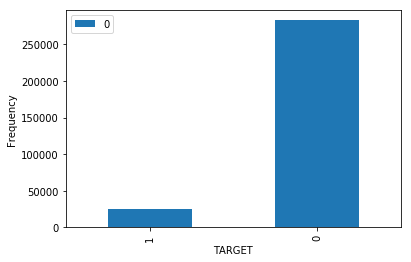

```python
#Target Variable
df=pd.DataFrame(App.groupby('TARGET').size())
df=df.sort_values(by=[0])
print(df.head(10))
print(df.tail(10))
df.plot(kind='bar')
#plt.ylim(0, 1000)
plt.ylabel('Frequency')
```

```python
print(24825/307511*100)
print('Percentage of Defaults in Dataset')
```

```
8.072881945686495
Percentage of Defaults in Dataset
```

### Data is highly unbalanced, the chance of finding a default case is ~8%.

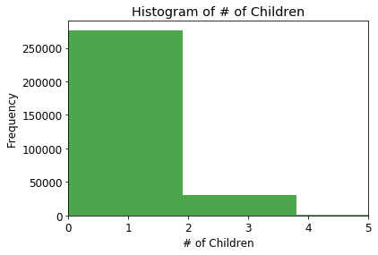

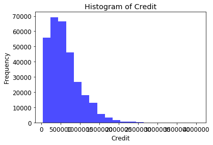

```python
#Children
n, bins, patches = plt.hist(App.CNT_CHILDREN, facecolor='green', alpha=0.7)
plt.xlim(0, 5)
plt.title('Histogram of # of Children')
plt.xlabel("# of Children")
plt.ylabel("Frequency")
plt.show()
#Credit
n, bins, patches = plt.hist(App.AMT_CREDIT,20, facecolor='blue', alpha=0.7)
plt.title('Histogram of Credit')
plt.xlabel("Credit")
plt.ylabel("Frequency")
plt.show()
```

```
                              TARGET  CNT_CHILDREN  AMT_INCOME_TOTAL  \
TARGET                      1.000000      0.020272         -0.022853
CNT_CHILDREN                0.020272      1.000000          0.039827
AMT_INCOME_TOTAL           -0.022853      0.039827          1.000000
AMT_CREDIT                 -0.051372     -0.002967          0.392784
AMT_ANNUITY                -0.026518      0.014328          0.461884
AMT_GOODS_PRICE            -0.057561     -0.007274          0.401131
REGION_POPULATION_RELATIVE -0.036840     -0.012079          0.196761
DAYS_BIRTH                  0.065340      0.328014          0.088112
DAYS_EMPLOYED              -0.027481     -0.229761         -0.168675
DAYS_REGISTRATION           0.040470      0.192284          0.088619
DAYS_ID_PUBLISH             0.070087     -0.009033          0.029824
OWN_CAR_AGE                 0.006573      0.102935          0.039469
FLAG_WORK_PHONE             0.014762      0.048055         -0.034441
FLAG_PHONE                 -0.013359     -0.025902          0.018784
CNT_FAM_MEMBERS             0.012691      0.874937          0.051794
HOUR_APPR_PROCESS_START    -0.034850     -0.014862          0.084983
EXT_SOURCE_1               -0.068088      0.028200          0.106050
EXT_SOURCE_2               -0.167193     -0.015320          0.158501
EXT_SOURCE_3               -0.142900     -0.014696         -0.001867
OBS_30_CNT_SOCIAL_CIRCLE    0.025341      0.001680         -0.039407
DEF_30_CNT_SOCIAL_CIRCLE    0.067052      0.000004         -0.049073
OBS_60_CNT_SOCIAL_CIRCLE    0.024542      0.001363         -0.039453
DAYS_LAST_PHONE_CHANGE      0.060659      0.018745         -0.012531
AMT_REQ_CREDIT_BUREAU_MON  -0.014624     -0.000243          0.091464
AMT_REQ_CREDIT_BUREAU_QRT   0.000554     -0.002399          0.007050
AMT_REQ_CREDIT_BUREAU_YEAR -0.002090     -0.023498          0.045566
FRIDAY                     -0.015914      0.011716          0.015283
MONDAY                      0.000782      0.008574         -0.013704
THURSDAY                    0.023513      0.013333         -0.016153
TUESDAY                    -0.006852     -0.023009         -0.013500
WEDNESDAY                   0.003403     -0.008592          0.009305
Business Entity Type 3      0.028514      0.030906          0.126389

                            AMT_CREDIT  AMT_ANNUITY  AMT_GOODS_PRICE  \
TARGET                       -0.051372    -0.026518        -0.057561
CNT_CHILDREN                 -0.002967     0.014328        -0.007274
AMT_INCOME_TOTAL              0.392784     0.461884         0.401131
AMT_CREDIT                    1.000000     0.787057         0.986446
AMT_ANNUITY                   0.787057     1.000000         0.789345
```

[output cut: 286 more lines]

```
OBS_30_CNT_SOCIAL_CIRCLE                 -0.028819
DEF_30_CNT_SOCIAL_CIRCLE                 -0.012002
OBS_60_CNT_SOCIAL_CIRCLE                 -0.028081
DAYS_LAST_PHONE_CHANGE                    0.008256
AMT_REQ_CREDIT_BUREAU_MON                 0.026564
AMT_REQ_CREDIT_BUREAU_QRT                -0.002939
AMT_REQ_CREDIT_BUREAU_YEAR               -0.003197
FRIDAY                                    0.003012
MONDAY                                   -0.001187
THURSDAY                                  0.001385
TUESDAY                                  -0.008950
WEDNESDAY                                -0.006349
Business Entity Type 3                    1.000000

[32 rows x 32 columns]
```

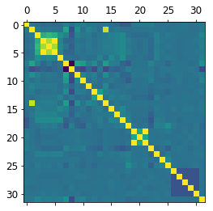

```python
#Correlation Analysis on Numerical Values
print(App_Data.corr())
# Visual
plt.matshow(App_Data.corr())
# None of the variables show particularly high correlation.
## COUNT FAMILY MEMEBRS IS HIGHLY CORRELATED WITH CNT_CHILDREN
```

Correlation Matrix shows Count Family Members and Count Children are 87% correlated. This could be cause for multicollinearity during analysis.

```python
#Look for missing values
App.isnull().sum()
```

```
SK_ID_CURR                           0
TARGET                               0
NAME_CONTRACT_TYPE                   0
CODE_GENDER                          0
FLAG_OWN_CAR                         0
FLAG_OWN_REALTY                      0
CNT_CHILDREN                         0
AMT_INCOME_TOTAL                     0
AMT_CREDIT                           0
AMT_ANNUITY                         12
AMT_GOODS_PRICE                    278
NAME_TYPE_SUITE                   1292
NAME_INCOME_TYPE                     0
NAME_EDUCATION_TYPE                  0
NAME_FAMILY_STATUS                   0
NAME_HOUSING_TYPE                    0
REGION_POPULATION_RELATIVE           0
DAYS_BIRTH                           0
DAYS_EMPLOYED                        0
DAYS_REGISTRATION                    0
DAYS_ID_PUBLISH                      0
OWN_CAR_AGE                     202929
FLAG_MOBIL                           0
FLAG_EMP_PHONE                       0
FLAG_WORK_PHONE                      0
FLAG_CONT_MOBILE                     0
FLAG_PHONE                           0
FLAG_EMAIL                           0
OCCUPATION_TYPE                  96391
CNT_FAM_MEMBERS                      2
REGION_RATING_CLIENT                 0
REGION_RATING_CLIENT_W_CITY          0
WEEKDAY_APPR_PROCESS_START           0
HOUR_APPR_PROCESS_START              0
REG_REGION_NOT_LIVE_REGION           0
REG_REGION_NOT_WORK_REGION           0
LIVE_REGION_NOT_WORK_REGION          0
REG_CITY_NOT_LIVE_CITY               0
REG_CITY_NOT_WORK_CITY               0
LIVE_CITY_NOT_WORK_CITY              0
```

[output cut: 68 more lines]

```
FLAG_DOCUMENT_14                     0
FLAG_DOCUMENT_15                     0
FLAG_DOCUMENT_16                     0
FLAG_DOCUMENT_17                     0
FLAG_DOCUMENT_18                     0
FLAG_DOCUMENT_19                     0
FLAG_DOCUMENT_20                     0
FLAG_DOCUMENT_21                     0
AMT_REQ_CREDIT_BUREAU_HOUR       41519
AMT_REQ_CREDIT_BUREAU_DAY        41519
AMT_REQ_CREDIT_BUREAU_WEEK       41519
AMT_REQ_CREDIT_BUREAU_MON        41519
AMT_REQ_CREDIT_BUREAU_QRT        41519
AMT_REQ_CREDIT_BUREAU_YEAR       41519
dtype: int64
```

```
Text(0.5,1,'ORGANIZATION_TYPE vs TARGET')
```

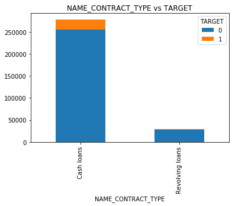

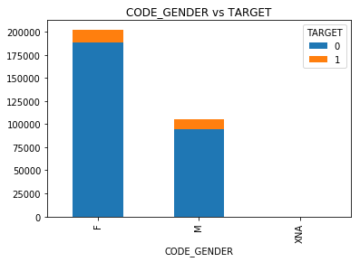

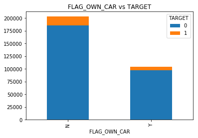

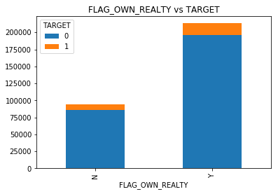

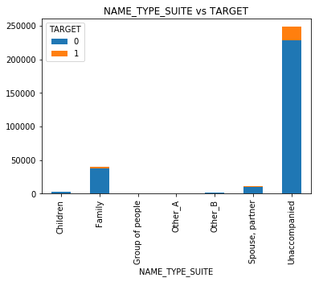

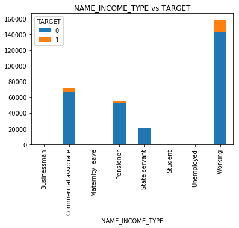

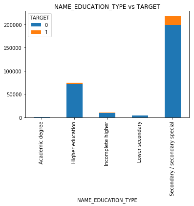

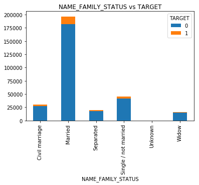

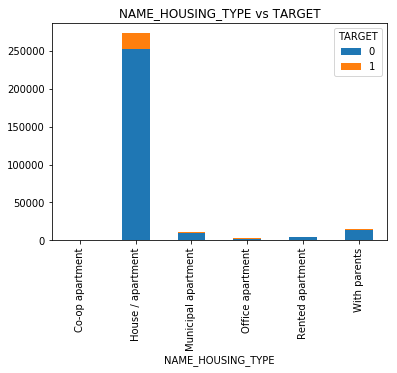

[figure not shown]

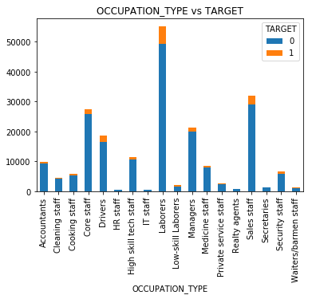

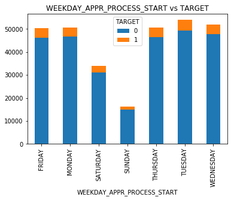

[1 more figures not shown]

```python
df = App
#Contract Type
c1 = 'NAME_CONTRACT_TYPE'
c2 = 'TARGET'
####df[category2] = np.where(df['hours-per-week']>= 40, 'Over 40hrs', 'Under 40hrs')
crosstab = pd.crosstab(df[c1], df[c2],colnames=[c2],rownames=[c1])
#Bar plot
crosstab.plot(kind='bar', stacked=True)
plt.title(c1 + ' vs ' + c2)
#Code Gender
c1 = 'CODE_GENDER'
c2 = 'TARGET'
crosstab = pd.crosstab(df[c1], df[c2],colnames=[c2],rownames=[c1])
#Bar plot
crosstab.plot(kind='bar', stacked=True)
plt.title(c1 + ' vs ' + c2)
#Code Own Care
c1 = 'FLAG_OWN_CAR'
c2 = 'TARGET'
crosstab = pd.crosstab(df[c1], df[c2],colnames=[c2],rownames=[c1])
#Bar plot
crosstab.plot(kind='bar', stacked=True)
plt.title(c1 + ' vs ' + c2)
#Code Own Realty
c1 = 'FLAG_OWN_REALTY'
c2 = 'TARGET'
crosstab = pd.crosstab(df[c1], df[c2],colnames=[c2],rownames=[c1])
#Bar plot
crosstab.plot(kind='bar', stacked=True)
plt.title(c1 + ' vs ' + c2)
#Code Name Type Suite
c1 = 'NAME_TYPE_SUITE'
c2 = 'TARGET'
crosstab = pd.crosstab(df[c1], df[c2],colnames=[c2],rownames=[c1])
#Bar plot
crosstab.plot(kind='bar', stacked=True)
plt.title(c1 + ' vs ' + c2)
#Code Income Type
c1 = 'NAME_INCOME_TYPE'
c2 = 'TARGET'
crosstab = pd.crosstab(df[c1], df[c2],colnames=[c2],rownames=[c1])
#Bar plot
crosstab.plot(kind='bar', stacked=True)
plt.title(c1 + ' vs ' + c2)
#Code Education
c1 = 'NAME_EDUCATION_TYPE'
c2 = 'TARGET'
crosstab = pd.crosstab(df[c1], df[c2],colnames=[c2],rownames=[c1])
#Bar plot
crosstab.plot(kind='bar', stacked=True)
plt.title(c1 + ' vs ' + c2)
#Code Family Status
c1 = 'NAME_FAMILY_STATUS'
c2 = 'TARGET'
crosstab = pd.crosstab(df[c1], df[c2],colnames=[c2],rownames=[c1])
#Bar plot
crosstab.plot(kind='bar', stacked=True)
plt.title(c1 + ' vs ' + c2)
#Code Housing Type
c1 = 'NAME_HOUSING_TYPE'
c2 = 'TARGET'
crosstab = pd.crosstab(df[c1], df[c2],colnames=[c2],rownames=[c1])
#Bar plot
crosstab.plot(kind='bar', stacked=True)
plt.title(c1 + ' vs ' + c2)
#Code Occupation
c1 = 'OCCUPATION_TYPE'
c2 = 'TARGET'
crosstab = pd.crosstab(df[c1], df[c2],colnames=[c2],rownames=[c1])
#Bar plot
crosstab.plot(kind='bar', stacked=True)
plt.title(c1 + ' vs ' + c2)
#Code Weekday Approval Process Start
c1 = 'WEEKDAY_APPR_PROCESS_START'
c2 = 'TARGET'
crosstab = pd.crosstab(df[c1], df[c2],colnames=[c2],rownames=[c1])
#Bar plot
crosstab.plot(kind='bar', stacked=True)
plt.title(c1 + ' vs ' + c2)
#Code Organization Type
c1 = 'ORGANIZATION_TYPE'
c2 = 'TARGET'
crosstab = pd.crosstab(df[c1], df[c2],colnames=[c2],rownames=[c1])
#Bar plot
crosstab.plot(kind='bar', stacked=True)
plt.title(c1 + ' vs ' + c2)
```

EDA Insights:

~2/3 are women.

~2/3 don't own a car.

~2/3 do own realty.

### 2: Data Munging & Feature Selection

Due to the sheer number of features and Columns 44 through 90 are missing over 50% of their data I decided to remove those columns.

```python
#Remove Columns 44:90, columns are missing over 50% of data.
App_Red = App.drop(columns=['APARTMENTS_AVG',
'BASEMENTAREA_AVG',
'YEARS_BEGINEXPLUATATION_AVG',
'YEARS_BUILD_AVG',
'COMMONAREA_AVG',
'ELEVATORS_AVG',
'ENTRANCES_AVG',
'FLOORSMAX_AVG',
'FLOORSMIN_AVG',
'LANDAREA_AVG',
'LIVINGAPARTMENTS_AVG',
'LIVINGAREA_AVG',
'NONLIVINGAPARTMENTS_AVG',
'NONLIVINGAREA_AVG',
'APARTMENTS_MODE',
'BASEMENTAREA_MODE',
'YEARS_BEGINEXPLUATATION_MODE',
'YEARS_BUILD_MODE',
'COMMONAREA_MODE',
'ELEVATORS_MODE',
'ENTRANCES_MODE',
'FLOORSMAX_MODE',
'FLOORSMIN_MODE',
'LANDAREA_MODE',
'LIVINGAPARTMENTS_MODE',
'LIVINGAREA_MODE',
'NONLIVINGAPARTMENTS_MODE',
'NONLIVINGAREA_MODE',
'APARTMENTS_MEDI',
'BASEMENTAREA_MEDI',
'YEARS_BEGINEXPLUATATION_MEDI',
'YEARS_BUILD_MEDI',
'COMMONAREA_MEDI',
'ELEVATORS_MEDI',
'ENTRANCES_MEDI',
'FLOORSMAX_MEDI',
'FLOORSMIN_MEDI',
'LANDAREA_MEDI',
'LIVINGAPARTMENTS_MEDI',
'LIVINGAREA_MEDI',
'NONLIVINGAPARTMENTS_MEDI',
'NONLIVINGAREA_MEDI',
'FONDKAPREMONT_MODE',
'HOUSETYPE_MODE',
'TOTALAREA_MODE',
'WALLSMATERIAL_MODE',
'EMERGENCYSTATE_MODE'])
App_Red.head(10)
```

|  | SK_ID_CURR | TARGET | NAME_CONTRACT_TYPE | CODE_GENDER | FLAG_OWN_CAR | FLAG_OWN_REALTY | CNT_CHILDREN | AMT_INCOME_TOTAL | AMT_CREDIT | AMT_ANNUITY | ... | FLAG_DOCUMENT_18 | FLAG_DOCUMENT_19 | FLAG_DOCUMENT_20 | FLAG_DOCUMENT_21 | AMT_REQ_CREDIT_BUREAU_HOUR | AMT_REQ_CREDIT_BUREAU_DAY | AMT_REQ_CREDIT_BUREAU_WEEK | AMT_REQ_CREDIT_BUREAU_MON | AMT_REQ_CREDIT_BUREAU_QRT | AMT_REQ_CREDIT_BUREAU_YEAR |
| --- | --- | --- | --- | --- | --- | --- | --- | --- | --- | --- | --- | --- | --- | --- | --- | --- | --- | --- | --- | --- | --- |
| 0 | 100002 | 1 | Cash loans | M | N | Y | 0 | 202500.0 | 406597.5 | 24700.5 | ... | 0 | 0 | 0 | 0 | 0.0 | 0.0 | 0.0 | 0.0 | 0.0 | 1.0 |
| 1 | 100003 | 0 | Cash loans | F | N | N | 0 | 270000.0 | 1293502.5 | 35698.5 | ... | 0 | 0 | 0 | 0 | 0.0 | 0.0 | 0.0 | 0.0 | 0.0 | 0.0 |
| 2 | 100004 | 0 | Revolving loans | M | Y | Y | 0 | 67500.0 | 135000.0 | 6750.0 | ... | 0 | 0 | 0 | 0 | 0.0 | 0.0 | 0.0 | 0.0 | 0.0 | 0.0 |
| 3 | 100006 | 0 | Cash loans | F | N | Y | 0 | 135000.0 | 312682.5 | 29686.5 | ... | 0 | 0 | 0 | 0 | NaN | NaN | NaN | NaN | NaN | NaN |
| 4 | 100007 | 0 | Cash loans | M | N | Y | 0 | 121500.0 | 513000.0 | 21865.5 | ... | 0 | 0 | 0 | 0 | 0.0 | 0.0 | 0.0 | 0.0 | 0.0 | 0.0 |
| 5 | 100008 | 0 | Cash loans | M | N | Y | 0 | 99000.0 | 490495.5 | 27517.5 | ... | 0 | 0 | 0 | 0 | 0.0 | 0.0 | 0.0 | 0.0 | 1.0 | 1.0 |
| 6 | 100009 | 0 | Cash loans | F | Y | Y | 1 | 171000.0 | 1560726.0 | 41301.0 | ... | 0 | 0 | 0 | 0 | 0.0 | 0.0 | 0.0 | 1.0 | 1.0 | 2.0 |
| 7 | 100010 | 0 | Cash loans | M | Y | Y | 0 | 360000.0 | 1530000.0 | 42075.0 | ... | 0 | 0 | 0 | 0 | 0.0 | 0.0 | 0.0 | 0.0 | 0.0 | 0.0 |
| 8 | 100011 | 0 | Cash loans | F | N | Y | 0 | 112500.0 | 1019610.0 | 33826.5 | ... | 0 | 0 | 0 | 0 | 0.0 | 0.0 | 0.0 | 0.0 | 0.0 | 1.0 |
| 9 | 100012 | 0 | Revolving loans | M | N | Y | 0 | 135000.0 | 405000.0 | 20250.0 | ... | 0 | 0 | 0 | 0 | NaN | NaN | NaN | NaN | NaN | NaN |

10 rows × 75 columns

```python
print(App_Red.shape)
App_Red.isnull().sum()
```

```
(307511, 75)
```

```
SK_ID_CURR                          0
TARGET                              0
NAME_CONTRACT_TYPE                  0
CODE_GENDER                         0
FLAG_OWN_CAR                        0
FLAG_OWN_REALTY                     0
CNT_CHILDREN                        0
AMT_INCOME_TOTAL                    0
AMT_CREDIT                          0
AMT_ANNUITY                        12
AMT_GOODS_PRICE                   278
NAME_TYPE_SUITE                  1292
NAME_INCOME_TYPE                    0
NAME_EDUCATION_TYPE                 0
NAME_FAMILY_STATUS                  0
NAME_HOUSING_TYPE                   0
REGION_POPULATION_RELATIVE          0
DAYS_BIRTH                          0
DAYS_EMPLOYED                       0
DAYS_REGISTRATION                   0
DAYS_ID_PUBLISH                     0
OWN_CAR_AGE                    202929
FLAG_MOBIL                          0
FLAG_EMP_PHONE                      0
FLAG_WORK_PHONE                     0
FLAG_CONT_MOBILE                    0
FLAG_PHONE                          0
FLAG_EMAIL                          0
OCCUPATION_TYPE                 96391
CNT_FAM_MEMBERS                     2
REGION_RATING_CLIENT                0
REGION_RATING_CLIENT_W_CITY         0
WEEKDAY_APPR_PROCESS_START          0
HOUR_APPR_PROCESS_START             0
REG_REGION_NOT_LIVE_REGION          0
REG_REGION_NOT_WORK_REGION          0
LIVE_REGION_NOT_WORK_REGION         0
REG_CITY_NOT_LIVE_CITY              0
REG_CITY_NOT_WORK_CITY              0
LIVE_CITY_NOT_WORK_CITY             0
```

[output cut: 21 more lines]

```
FLAG_DOCUMENT_14                    0
FLAG_DOCUMENT_15                    0
FLAG_DOCUMENT_16                    0
FLAG_DOCUMENT_17                    0
FLAG_DOCUMENT_18                    0
FLAG_DOCUMENT_19                    0
FLAG_DOCUMENT_20                    0
FLAG_DOCUMENT_21                    0
AMT_REQ_CREDIT_BUREAU_HOUR      41519
AMT_REQ_CREDIT_BUREAU_DAY       41519
AMT_REQ_CREDIT_BUREAU_WEEK      41519
AMT_REQ_CREDIT_BUREAU_MON       41519
AMT_REQ_CREDIT_BUREAU_QRT       41519
AMT_REQ_CREDIT_BUREAU_YEAR      41519
dtype: int64
```

### Creating Dummies

```python
#Making Dummies
Contract_d = pd.DataFrame(pd.get_dummies(App_Red['NAME_CONTRACT_TYPE']))
Gender_d = pd.DataFrame(pd.get_dummies(App_Red['CODE_GENDER']))
Car_d = pd.DataFrame(pd.get_dummies(App_Red['FLAG_OWN_CAR']))
Realty_d = pd.DataFrame(pd.get_dummies(App_Red['FLAG_OWN_REALTY']))
Suite_d = pd.DataFrame(pd.get_dummies(App_Red['NAME_TYPE_SUITE']))
Income_d = pd.DataFrame(pd.get_dummies(App_Red['NAME_INCOME_TYPE']))
Education_d = pd.DataFrame(pd.get_dummies(App_Red['NAME_EDUCATION_TYPE']))
Fam_d = pd.DataFrame(pd.get_dummies(App_Red['NAME_FAMILY_STATUS']))
Housing_d = pd.DataFrame(pd.get_dummies(App_Red['NAME_HOUSING_TYPE']))
Occupation_d = pd.DataFrame(pd.get_dummies(App_Red['OCCUPATION_TYPE']))
Weekday_d = pd.DataFrame(pd.get_dummies(App_Red['WEEKDAY_APPR_PROCESS_START']))
Org_d = pd.DataFrame(pd.get_dummies(App_Red['ORGANIZATION_TYPE']))
```

Placing dummies in dataframe. Removing categorical variables.

```python
#Combining Dummies into Dataframe
App_Red_d = pd.concat([App_Red,Contract_d,Gender_d,Car_d,Realty_d,Suite_d,Income_d,Education_d,Fam_d,Housing_d,Occupation_d,Weekday_d,Org_d], axis=1)
#Remove Categorical Columns
#Remove ID Column, not useful
App_Red_d = App_Red_d.drop(columns=['SK_ID_CURR','NAME_CONTRACT_TYPE','CODE_GENDER','FLAG_OWN_CAR','FLAG_OWN_REALTY','NAME_TYPE_SUITE','NAME_INCOME_TYPE','NAME_EDUCATION_TYPE','NAME_FAMILY_STATUS','NAME_HOUSING_TYPE','OCCUPATION_TYPE','WEEKDAY_APPR_PROCESS_START','ORGANIZATION_TYPE'])
print(App_Red_d.head(10))
print(App_Red_d.shape)
```

```
   TARGET  CNT_CHILDREN  AMT_INCOME_TOTAL  AMT_CREDIT  AMT_ANNUITY  \
0       1             0          202500.0    406597.5      24700.5
1       0             0          270000.0   1293502.5      35698.5
2       0             0           67500.0    135000.0       6750.0
3       0             0          135000.0    312682.5      29686.5
4       0             0          121500.0    513000.0      21865.5
5       0             0           99000.0    490495.5      27517.5
6       0             1          171000.0   1560726.0      41301.0
7       0             0          360000.0   1530000.0      42075.0
8       0             0          112500.0   1019610.0      33826.5
9       0             0          135000.0    405000.0      20250.0

   AMT_GOODS_PRICE  REGION_POPULATION_RELATIVE  DAYS_BIRTH  DAYS_EMPLOYED  \
0         351000.0                    0.018801       -9461           -637
1        1129500.0                    0.003541      -16765          -1188
```

[output cut: 47 more lines]

```python
#App_Red_d = App_Red_d.fillna(0)
#print(App_Red_d.dtypes)
App_Red_d.isnull().sum()
```

```
TARGET                           0
CNT_CHILDREN                     0
AMT_INCOME_TOTAL                 0
AMT_CREDIT                       0
AMT_ANNUITY                      0
AMT_GOODS_PRICE                  0
REGION_POPULATION_RELATIVE       0
DAYS_BIRTH                       0
DAYS_EMPLOYED                    0
DAYS_REGISTRATION                0
DAYS_ID_PUBLISH                  0
OWN_CAR_AGE                      0
FLAG_MOBIL                       0
FLAG_EMP_PHONE                   0
FLAG_WORK_PHONE                  0
FLAG_CONT_MOBILE                 0
FLAG_PHONE                       0
FLAG_EMAIL                       0
CNT_FAM_MEMBERS                  0
REGION_RATING_CLIENT             0
REGION_RATING_CLIENT_W_CITY      0
HOUR_APPR_PROCESS_START          0
REG_REGION_NOT_LIVE_REGION       0
REG_REGION_NOT_WORK_REGION       0
LIVE_REGION_NOT_WORK_REGION      0
REG_CITY_NOT_LIVE_CITY           0
REG_CITY_NOT_WORK_CITY           0
LIVE_CITY_NOT_WORK_CITY          0
EXT_SOURCE_1                     0
EXT_SOURCE_2                     0
EXT_SOURCE_3                     0
OBS_30_CNT_SOCIAL_CIRCLE         0
DEF_30_CNT_SOCIAL_CIRCLE         0
OBS_60_CNT_SOCIAL_CIRCLE         0
DEF_60_CNT_SOCIAL_CIRCLE         0
DAYS_LAST_PHONE_CHANGE           0
FLAG_DOCUMENT_2                  0
FLAG_DOCUMENT_3                  0
FLAG_DOCUMENT_4                  0
FLAG_DOCUMENT_5                  0
```

[output cut: 132 more lines]

```
Telecom                          0
Trade: type 1                    0
Trade: type 2                    0
Trade: type 3                    0
Trade: type 4                    0
Trade: type 5                    0
Trade: type 6                    0
Trade: type 7                    0
Transport: type 1                0
Transport: type 2                0
Transport: type 3                0
Transport: type 4                0
University                       0
XNA                              0
dtype: int64
```

```python
#Viewing all variables to validate none are duplicates/misnomers.
#pd.set_option('display.max_rows', 500) #Display all variables
#App_Red_d.dtypes
App_Red_d
```

|  | TARGET | CNT_CHILDREN | AMT_INCOME_TOTAL | AMT_CREDIT | AMT_ANNUITY | AMT_GOODS_PRICE | REGION_POPULATION_RELATIVE | DAYS_BIRTH | DAYS_EMPLOYED | DAYS_REGISTRATION | ... | Trade: type 4 | Trade: type 5 | Trade: type 6 | Trade: type 7 | Transport: type 1 | Transport: type 2 | Transport: type 3 | Transport: type 4 | University | XNA |
| --- | --- | --- | --- | --- | --- | --- | --- | --- | --- | --- | --- | --- | --- | --- | --- | --- | --- | --- | --- | --- | --- |
| 0 | 1 | 0 | 202500.000 | 406597.5 | 24700.5 | 351000.0 | 0.018801 | -9461 | -637 | -3648.0 | ... | 0 | 0 | 0 | 0 | 0 | 0 | 0 | 0 | 0 | 0 |
| 1 | 0 | 0 | 270000.000 | 1293502.5 | 35698.5 | 1129500.0 | 0.003541 | -16765 | -1188 | -1186.0 | ... | 0 | 0 | 0 | 0 | 0 | 0 | 0 | 0 | 0 | 0 |
| 2 | 0 | 0 | 67500.000 | 135000.0 | 6750.0 | 135000.0 | 0.010032 | -19046 | -225 | -4260.0 | ... | 0 | 0 | 0 | 0 | 0 | 0 | 0 | 0 | 0 | 0 |
| 3 | 0 | 0 | 135000.000 | 312682.5 | 29686.5 | 297000.0 | 0.008019 | -19005 | -3039 | -9833.0 | ... | 0 | 0 | 0 | 0 | 0 | 0 | 0 | 0 | 0 | 0 |
| 4 | 0 | 0 | 121500.000 | 513000.0 | 21865.5 | 513000.0 | 0.028663 | -19932 | -3038 | -4311.0 | ... | 0 | 0 | 0 | 0 | 0 | 0 | 0 | 0 | 0 | 0 |
| 5 | 0 | 0 | 99000.000 | 490495.5 | 27517.5 | 454500.0 | 0.035792 | -16941 | -1588 | -4970.0 | ... | 0 | 0 | 0 | 0 | 0 | 0 | 0 | 0 | 0 | 0 |
| 6 | 0 | 1 | 171000.000 | 1560726.0 | 41301.0 | 1395000.0 | 0.035792 | -13778 | -3130 | -1213.0 | ... | 0 | 0 | 0 | 0 | 0 | 0 | 0 | 0 | 0 | 0 |
| 7 | 0 | 0 | 360000.000 | 1530000.0 | 42075.0 | 1530000.0 | 0.003122 | -18850 | -449 | -4597.0 | ... | 0 | 0 | 0 | 0 | 0 | 0 | 0 | 0 | 0 | 0 |
| 8 | 0 | 0 | 112500.000 | 1019610.0 | 33826.5 | 913500.0 | 0.018634 | -20099 | 365243 | -7427.0 | ... | 0 | 0 | 0 | 0 | 0 | 0 | 0 | 0 | 0 | 1 |
| 9 | 0 | 0 | 135000.000 | 405000.0 | 20250.0 | 405000.0 | 0.019689 | -14469 | -2019 | -14437.0 | ... | 0 | 0 | 0 | 0 | 0 | 0 | 0 | 0 | 0 | 0 |
| 10 | 0 | 1 | 112500.000 | 652500.0 | 21177.0 | 652500.0 | 0.022800 | -10197 | -679 | -4427.0 | ... | 0 | 0 | 0 | 0 | 0 | 0 | 0 | 0 | 0 | 0 |
| 11 | 0 | 0 | 38419.155 | 148365.0 | 10678.5 | 135000.0 | 0.015221 | -20417 | 365243 | -5246.0 | ... | 0 | 0 | 0 | 0 | 0 | 0 | 0 | 0 | 0 | 1 |
| 12 | 0 | 0 | 67500.000 | 80865.0 | 5881.5 | 67500.0 | 0.031329 | -13439 | -2717 | -311.0 | ... | 0 | 0 | 0 | 0 | 0 | 0 | 0 | 0 | 0 | 0 |
| 13 | 0 | 1 | 225000.000 | 918468.0 | 28966.5 | 697500.0 | 0.016612 | -14086 | -3028 | -643.0 | ... | 0 | 0 | 0 | 0 | 0 | 0 | 0 | 0 | 0 | 0 |
| 14 | 0 | 0 | 189000.000 | 773680.5 | 32778.0 | 679500.0 | 0.010006 | -14583 | -203 | -615.0 | ... | 0 | 0 | 0 | 0 | 0 | 1 | 0 | 0 | 0 | 0 |
| 15 | 0 | 0 | 157500.000 | 299772.0 | 20160.0 | 247500.0 | 0.020713 | -8728 | -1157 | -3494.0 | ... | 0 | 0 | 0 | 0 | 0 | 0 | 0 | 0 | 0 | 0 |
| 16 | 0 | 0 | 108000.000 | 509602.5 | 26149.5 | 387000.0 | 0.018634 | -12931 | -1317 | -6392.0 | ... | 0 | 0 | 0 | 0 | 0 | 0 | 0 | 0 | 0 | 0 |
| 17 | 0 | 1 | 81000.000 | 270000.0 | 13500.0 | 270000.0 | 0.010966 | -9776 | -191 | -4143.0 | ... | 0 | 0 | 0 | 0 | 0 | 0 | 0 | 0 | 0 | 0 |
| 18 | 0 | 0 | 112500.000 | 157500.0 | 7875.0 | 157500.0 | 0.046220 | -17718 | -7804 | -8751.0 | ... | 0 | 0 | 0 | 0 | 0 | 0 | 0 | 0 | 0 | 0 |
| 19 | 0 | 1 | 90000.000 | 544491.0 | 17563.5 | 454500.0 | 0.015221 | -11348 | -2038 | -1021.0 | ... | 0 | 0 | 0 | 0 | 0 | 0 | 0 | 0 | 0 | 0 |
| 20 | 0 | 0 | 135000.000 | 427500.0 | 21375.0 | 427500.0 | 0.015221 | -18252 | -4286 | -298.0 | ... | 0 | 0 | 0 | 0 | 0 | 0 | 0 | 0 | 0 | 0 |
| 21 | 0 | 1 | 202500.000 | 1132573.5 | 37561.5 | 927000.0 | 0.025164 | -14815 | -1652 | -2299.0 | ... | 0 | 0 | 0 | 1 | 0 | 0 | 0 | 0 | 0 | 0 |
| 22 | 0 | 1 | 450000.000 | 497520.0 | 32521.5 | 450000.0 | 0.020713 | -11146 | -4306 | -114.0 | ... | 0 | 0 | 0 | 0 | 0 | 0 | 0 | 0 | 0 | 0 |
| 23 | 0 | 0 | 83250.000 | 239850.0 | 23850.0 | 225000.0 | 0.006296 | -24827 | 365243 | -9012.0 | ... | 0 | 0 | 0 | 0 | 0 | 0 | 0 | 0 | 0 | 1 |
| 24 | 0 | 2 | 135000.000 | 247500.0 | 12703.5 | 247500.0 | 0.026392 | -11286 | -746 | -108.0 | ... | 0 | 0 | 0 | 0 | 0 | 0 | 0 | 0 | 0 | 0 |
| 25 | 0 | 0 | 90000.000 | 225000.0 | 11074.5 | 225000.0 | 0.028663 | -19334 | -3494 | -2419.0 | ... | 0 | 0 | 0 | 0 | 0 | 0 | 0 | 0 | 0 | 0 |
| 26 | 1 | 0 | 112500.000 | 979992.0 | 27076.5 | 702000.0 | 0.018029 | -18724 | -2628 | -6573.0 | ... | 0 | 0 | 0 | 0 | 0 | 0 | 0 | 0 | 0 | 0 |
| 27 | 0 | 1 | 112500.000 | 327024.0 | 23827.5 | 270000.0 | 0.019101 | -15948 | -1234 | -5782.0 | ... | 0 | 0 | 0 | 0 | 0 | 0 | 0 | 0 | 0 | 0 |
| 28 | 0 | 0 | 270000.000 | 790830.0 | 57676.5 | 675000.0 | 0.046220 | -9994 | -1796 | -4668.0 | ... | 0 | 0 | 0 | 0 | 0 | 0 | 0 | 0 | 0 | 0 |
| 29 | 0 | 0 | 90000.000 | 180000.0 | 9000.0 | 180000.0 | 0.030755 | -10341 | -1010 | -4799.0 | ... | 0 | 0 | 0 | 0 | 0 | 0 | 0 | 0 | 0 | 0 |

[output cut: 471 more lines]

307511 rows × 186 columns

### Feature Selection using a Random Forest

```python
#Train/Test Split (70/30 since dataset is large) for Feature Selection
features_train, features_test, target_train, target_test = train_test_split(
    App_Red_d.iloc[:,1:].values, App_Red_d.iloc[:,0].values, test_size=0.30, random_state=0)
print(features_test.shape)
print(features_train.shape)
print(target_test.shape)
print(target_train.shape)
```

```
(92254, 185)
(215257, 185)
(92254,)
(215257,)
```

Even though Random Forests negates differences in scale, because this was my feature selection I was basing my entire analysis off of I wanted to make sure it was correct. So I did a Z-Score Scaling test to confirm the results were identical for feature importance.

```python
## Try Scaling ## CONFIRMED SCALING DOES NOT MATTER
from sklearn.preprocessing import StandardScaler
scaler = StandardScaler()
# Fit only to the training data
scaler.fit(features_train)
# Now apply the transformations to the data:
ft_scale = scaler.transform(features_train)
```

```
Feature ranking:
1. feature 28 (0.041526)
2. feature 29 (0.035772)
3. feature 6 (0.028411)
4. feature 9 (0.027734)
5. feature 8 (0.027004)
6. feature 34 (0.026828)
7. feature 1 (0.026409)
8. feature 20 (0.025844)
9. feature 5 (0.025751)
10. feature 3 (0.025719)
11. feature 2 (0.025673)
12. feature 4 (0.025003)
13. feature 60 (0.023840)
14. feature 7 (0.022339)
15. feature 27 (0.021129)
16. feature 32 (0.020203)
17. feature 30 (0.020115)
18. feature 17 (0.016556)
19. feature 0 (0.014506)
20. feature 59 (0.012454)
21. feature 15 (0.012038)
22. feature 58 (0.011502)
23. feature 10 (0.011288)
24. feature 125 (0.010743)
25. feature 69 (0.010616)
26. feature 68 (0.010585)
27. feature 126 (0.010527)
28. feature 124 (0.010400)
29. feature 120 (0.010348)
30. feature 13 (0.010328)
31. feature 31 (0.010265)
32. feature 132 (0.010202)
33. feature 121 (0.009994)
34. feature 91 (0.009403)
35. feature 76 (0.008983)
36. feature 18 (0.008874)
37. feature 19 (0.008829)
38. feature 33 (0.008533)
39. feature 122 (0.008351)
```

[output cut: 131 more lines]

```
171. feature 164 (0.000078)
172. feature 85 (0.000070)
173. feature 176 (0.000057)
174. feature 175 (0.000055)
175. feature 50 (0.000047)
176. feature 79 (0.000027)
177. feature 40 (0.000019)
178. feature 82 (0.000001)
179. feature 37 (0.000001)
180. feature 77 (0.000000)
181. feature 43 (0.000000)
182. feature 11 (0.000000)
183. feature 45 (0.000000)
184. feature 65 (0.000000)
185. feature 94 (0.000000)
```

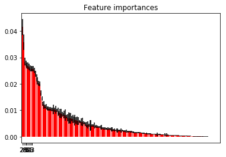

```python
from sklearn.ensemble import ExtraTreesClassifier
# Build a forest and compute the feature importances
import time
start_time = time.clock()
forest = ExtraTreesClassifier(n_estimators=250,
                              random_state=0)

forest.fit(ft_scale, target_train)
importances = forest.feature_importances_
std = np.std([tree.feature_importances_ for tree in forest.estimators_],
             axis=0)
indices = np.argsort(importances)[::-1]

# Print the feature ranking
print("Feature ranking:")

for f in range(ft_scale.shape[1]):
    print("%d. feature %d (%f)" % (f + 1, indices[f], importances[indices[f]]))

# Plot the feature importances of the forest
plt.figure()
plt.title("Feature importances")
plt.bar(range(ft_scale.shape[1]), importances[indices],
       color="r", yerr=std[indices], align="center")
plt.xticks(range(X.shape[1]), indices)
plt.xlim([-1, ft_scale.shape[1]])
plt.show()

print(time.clock() - start_time, "seconds")
```

```python
#Remove Columns Features with a relative value under .01
App_fs = App_Red_d.drop(columns=[
    'FLAG_MOBIL',
'FLAG_EMP_PHONE',
'FLAG_CONT_MOBILE',
'FLAG_EMAIL',
'REGION_RATING_CLIENT',
'REGION_RATING_CLIENT_W_CITY',
'REG_REGION_NOT_LIVE_REGION',
'REG_REGION_NOT_WORK_REGION',
'LIVE_REGION_NOT_WORK_REGION',
'REG_CITY_NOT_LIVE_CITY',
'REG_CITY_NOT_WORK_CITY',
'LIVE_CITY_NOT_WORK_CITY',
'DEF_60_CNT_SOCIAL_CIRCLE',
'FLAG_DOCUMENT_2',
'FLAG_DOCUMENT_3',
'FLAG_DOCUMENT_4',
'FLAG_DOCUMENT_5',
'FLAG_DOCUMENT_6',
'FLAG_DOCUMENT_7',
'FLAG_DOCUMENT_8',
'FLAG_DOCUMENT_9',
'FLAG_DOCUMENT_10',
'FLAG_DOCUMENT_11',
'FLAG_DOCUMENT_12',
'FLAG_DOCUMENT_13',
'FLAG_DOCUMENT_14',
'FLAG_DOCUMENT_15',
'FLAG_DOCUMENT_16',
'FLAG_DOCUMENT_17',
'FLAG_DOCUMENT_18',
'FLAG_DOCUMENT_19',
'FLAG_DOCUMENT_20',
'FLAG_DOCUMENT_21',
'AMT_REQ_CREDIT_BUREAU_HOUR',
'AMT_REQ_CREDIT_BUREAU_DAY',
'AMT_REQ_CREDIT_BUREAU_WEEK',
'Cash loans',
'Revolving loans',
'F',
'M',
'XNA',
'N',
'Y',
'Children',
'Family',
'Group of people',
'Other_A',
'Other_B',
'Spouse, partner',
'Unaccompanied',
'Businessman',
'Commercial associate',
'Maternity leave',
'Pensioner',
'State servant',
'Student',
'Unemployed',
'Working',
'Academic degree',
'Higher education',
'Incomplete higher',
'Lower secondary',
'Secondary / secondary special',
'Civil marriage',
'Married',
'Separated',
'Single / not married',
'Unknown',
'Widow',
'Co-op apartment',
'House / apartment',
'Municipal apartment',
'Office apartment',
'Rented apartment',
'With parents',
'Accountants',
'Cleaning staff',
'Cooking staff',
'Core staff',
'Drivers',
'HR staff',
'High skill tech staff',
'IT staff',
'Laborers',
'Low-skill Laborers',
'Managers',
'Medicine staff',
'Private service staff',
'Realty agents',
'Sales staff',
'Secretaries',
'Security staff',
'Waiters/barmen staff',
'SATURDAY',
'SUNDAY',
'Advertising',
'Agriculture',
'Bank',
'Business Entity Type 1',
'Business Entity Type 2',
'Cleaning',
'Construction',
'Culture',
'Electricity',
'Emergency',
'Government',
'Hotel',
'Housing',
'Industry: type 1',
'Industry: type 10',
'Industry: type 11',
'Industry: type 12',
'Industry: type 13',
'Industry: type 2',
'Industry: type 3',
'Industry: type 4',
'Industry: type 5',
'Industry: type 6',
'Industry: type 7',
'Industry: type 8',
'Industry: type 9',
'Insurance',
'Kindergarten',
'Legal Services',
'Medicine',
'Military',
'Mobile',
'Other',
'Police',
'Postal',
'Realtor',
'Religion',
'Restaurant',
'School',
'Security',
'Security Ministries',
'Self-employed',
'Services',
'Telecom',
'Trade: type 1',
'Trade: type 2',
'Trade: type 3',
'Trade: type 4',
'Trade: type 5',
'Trade: type 6',
'Trade: type 7',
'Transport: type 1',
'Transport: type 2',
'Transport: type 3',
'Transport: type 4',
'University',
'XNA'
])
App_fs.head(10)
```

|  | TARGET | CNT_CHILDREN | AMT_INCOME_TOTAL | AMT_CREDIT | AMT_ANNUITY | AMT_GOODS_PRICE | REGION_POPULATION_RELATIVE | DAYS_BIRTH | DAYS_EMPLOYED | DAYS_REGISTRATION | ... | DAYS_LAST_PHONE_CHANGE | AMT_REQ_CREDIT_BUREAU_MON | AMT_REQ_CREDIT_BUREAU_QRT | AMT_REQ_CREDIT_BUREAU_YEAR | FRIDAY | MONDAY | THURSDAY | TUESDAY | WEDNESDAY | Business Entity Type 3 |
| --- | --- | --- | --- | --- | --- | --- | --- | --- | --- | --- | --- | --- | --- | --- | --- | --- | --- | --- | --- | --- | --- |
| 0 | 1 | 0 | 202500.0 | 406597.5 | 24700.5 | 351000.0 | 0.018801 | -9461 | -637 | -3648.0 | ... | -1134.0 | 0.0 | 0.0 | 1.0 | 0 | 0 | 0 | 0 | 1 | 1 |
| 1 | 0 | 0 | 270000.0 | 1293502.5 | 35698.5 | 1129500.0 | 0.003541 | -16765 | -1188 | -1186.0 | ... | -828.0 | 0.0 | 0.0 | 0.0 | 0 | 1 | 0 | 0 | 0 | 0 |
| 2 | 0 | 0 | 67500.0 | 135000.0 | 6750.0 | 135000.0 | 0.010032 | -19046 | -225 | -4260.0 | ... | -815.0 | 0.0 | 0.0 | 0.0 | 0 | 1 | 0 | 0 | 0 | 0 |
| 3 | 0 | 0 | 135000.0 | 312682.5 | 29686.5 | 297000.0 | 0.008019 | -19005 | -3039 | -9833.0 | ... | -617.0 | 0.0 | 0.0 | 0.0 | 0 | 0 | 0 | 0 | 1 | 1 |
| 4 | 0 | 0 | 121500.0 | 513000.0 | 21865.5 | 513000.0 | 0.028663 | -19932 | -3038 | -4311.0 | ... | -1106.0 | 0.0 | 0.0 | 0.0 | 0 | 0 | 1 | 0 | 0 | 0 |
| 5 | 0 | 0 | 99000.0 | 490495.5 | 27517.5 | 454500.0 | 0.035792 | -16941 | -1588 | -4970.0 | ... | -2536.0 | 0.0 | 1.0 | 1.0 | 0 | 0 | 0 | 0 | 1 | 0 |
| 6 | 0 | 1 | 171000.0 | 1560726.0 | 41301.0 | 1395000.0 | 0.035792 | -13778 | -3130 | -1213.0 | ... | -1562.0 | 1.0 | 1.0 | 2.0 | 0 | 0 | 0 | 0 | 0 | 1 |
| 7 | 0 | 0 | 360000.0 | 1530000.0 | 42075.0 | 1530000.0 | 0.003122 | -18850 | -449 | -4597.0 | ... | -1070.0 | 0.0 | 0.0 | 0.0 | 0 | 1 | 0 | 0 | 0 | 0 |
| 8 | 0 | 0 | 112500.0 | 1019610.0 | 33826.5 | 913500.0 | 0.018634 | -20099 | 365243 | -7427.0 | ... | 0.0 | 0.0 | 0.0 | 1.0 | 0 | 0 | 0 | 0 | 1 | 0 |
| 9 | 0 | 0 | 135000.0 | 405000.0 | 20250.0 | 405000.0 | 0.019689 | -14469 | -2019 | -14437.0 | ... | -1673.0 | 0.0 | 0.0 | 0.0 | 0 | 0 | 1 | 0 | 0 | 0 |

10 rows × 32 columns

```python
App_fs.shape
# IF NEEDED
#App_Red_d = App_Red_d.fillna(0)
```

```
(307511, 32)
```

Scaling data down/up for quick iterations. I used below to pick smaller datasets to iterate through analysis quickly, especially for longer running algorithms.

```python
App_Data = App_fs#[:50000]
App_Data.shape
```

[output not shown]

```python
import warnings
warnings.filterwarnings("ignore")
```

### 3: Predictive Models (Note #Best Model at the top of a model in each subset indicates best performing model after tuning.)

Test/Train Split

```python
#Train/Test Split (70/30 since dataset is large) for Feature Selection
features_train, features_test, target_train, target_test = train_test_split(
    App_Data.iloc[:,1:].values, App_Data.iloc[:,0].values, test_size=0.30, random_state=0)
print(features_test.shape)
print(features_train.shape)
print(target_test.shape)
print(target_train.shape)
```

[output not shown]

### KNN

```python
## KNN BEST MODEL
from sklearn.neighbors import KNeighborsClassifier
neigh = KNeighborsClassifier(n_neighbors=10)
neigh_knn = neigh.fit(features_train, target_train)
target_predicted_knn = neigh_knn.predict(features_test)
```

```python
# use a full grid over several parameters and cross validate 5 times
from sklearn.model_selection import GridSearchCV
#param_grid = {"alpha": [.01,.1, .5, 1, 2]}
param_grid={"n_neighbors": [10,15,1]} #this does a range 1 through 10 changes by a factor of 1.
#param_grid={"n_neighbors": [10,15,1]} #this does a range 1 through 1 changes by a factor of .05

# run grid search
grid_search = GridSearchCV(neigh, param_grid=param_grid,n_jobs=-1,cv=5)
grid_search.fit(features_train, target_train)
print("Grid Scores", grid_search.cv_results_)
print("Best", grid_search.best_params_)
```

```
Grid Scores {'mean_fit_time': array([0.00734243, 0.00484562, 0.00768504]), 'std_fit_time': array([0.0011978 , 0.00014559, 0.00139159]), 'mean_score_time': array([0.02627788, 0.03433313, 0.04004831]), 'std_score_time': array([0.00215555, 0.01820538, 0.00735739]), 'param_n_neighbors': masked_array(dat…
             mask=[False, False, False],
       fill_value='?',
            dtype=object), 'params': [{'n_neighbors': 10}, {'n_neighbors': 15}, {'n_neighbors': 1}], 'split0_test_score': array([0.92285714, 0.92285714, 0.86857143]), 'split1_test_score': array([0.92142857, 0.92285714, 0.86857143]), 'split2_test_score': array([0.92285714, 0.92285714, 0.85      ]), '…
Best {'n_neighbors': 15}
```

```python
print("KNN Accuracy Score", accuracy_score(target_test, target_predicted_knn))
print("Classification Report")
print(classification_report(target_test, target_predicted_knn))
print("Confusion Matrix")
print(confusion_matrix(target_test, target_predicted_knn))
```

```
KNN Accuracy Score 0.9190666666666667
Classification Report
             precision    recall  f1-score   support

          0       0.92      1.00      0.96     13787
          1       0.33      0.00      0.00      1213

avg / total       0.87      0.92      0.88     15000

Confusion Matrix
[[13785     2]
 [ 1212     1]]
```

```python
### ROC AUC SCORE
## http://scikit-learn.org/stable/modules/generated/sklearn.metrics.roc_auc_score.html
from sklearn.metrics import roc_auc_score
target_predicted_knn_prob = neigh_knn.predict_proba(features_test)
roc_auc_score(target_test, target_predicted_knn_prob[:, 1])
```

```
0.5744953595938818
```

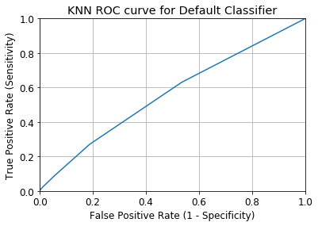

```python
fpr, tpr, thresholds = metrics.roc_curve(target_test, target_predicted_knn_prob[:, 1])
plt.plot(fpr, tpr)
plt.xlim([0.0, 1.0])
plt.ylim([0.0, 1.0])
plt.rcParams['font.size'] = 12
plt.title('KNN ROC curve for Default Classifier')
plt.xlabel('False Positive Rate (1 - Specificity)')
plt.ylabel('True Positive Rate (Sensitivity)')
plt.grid(True)
```

```python
#verify KNN with Cross Validation for KNN = 10
scores = cross_val_score(neigh_knn, features_train, target_train, cv=5)
print("Cross Validation Score for each K",scores)
scores.mean()
```

```
Cross Validation Score for each K [0.92285714 0.92142857 0.92285714 0.92285714 0.92285714]
```

```
0.9225714285714284
```

## Decision Trees

```python
from sklearn import tree
clf_dt = tree.DecisionTreeClassifier(max_depth=5, class_weight="balanced")
clf_dt = clf_dt.fit(features_train, target_train)
target_predicted_dt = clf_dt.predict(features_test)
print("DT Accuracy Score Max Depth = 5", accuracy_score(target_test, target_predicted_dt))
print("Classification Report")
print(classification_report(target_test, target_predicted_dt))
print("Confusion Matrix")
print(confusion_matrix(target_test, target_predicted_dt))
print('Area under the ROC Curve')
target_predicted_dt_prob = clf_dt.predict_proba(features_test)
roc_auc_score(target_test, target_predicted_dt_prob[:, 1])
```

```
DT Accuracy Score Max Depth = 5 0.6259333333333333
Classification Report
             precision    recall  f1-score   support

          0       0.96      0.62      0.75     13787
          1       0.13      0.67      0.22      1213

avg / total       0.89      0.63      0.71     15000

Confusion Matrix
[[8580 5207]
 [ 404  809]]
Area under the ROC Curve
```

```
0.6908256645940107
```

```python
from sklearn import tree
clf_dt = tree.DecisionTreeClassifier(max_depth=10, class_weight="balanced")
clf_dt = clf_dt.fit(features_train, target_train)
target_predicted_dt = clf_dt.predict(features_test)
print("DT Accuracy Score Max Depth = 10", accuracy_score(target_test, target_predicted_dt))
print("Classification Report")
print(classification_report(target_test, target_predicted_dt))
print("Confusion Matrix")
print(confusion_matrix(target_test, target_predicted_dt))
print('Area under the ROC Curve')
target_predicted_dt_prob = clf_dt.predict_proba(features_test)
roc_auc_score(target_test, target_predicted_dt_prob[:, 1])
```

```
DT Accuracy Score Max Depth = 10 0.6078
Classification Report
             precision    recall  f1-score   support

          0       0.95      0.61      0.74     13787
          1       0.12      0.62      0.20      1213

avg / total       0.88      0.61      0.70     15000

Confusion Matrix
[[8359 5428]
 [ 455  758]]
Area under the ROC Curve
```

```
0.6506095775492775
```

```python
#BEST MODEL
from sklearn import tree
clf_dt = tree.DecisionTreeClassifier(max_depth=2, class_weight="balanced")
clf_dt = clf_dt.fit(features_train, target_train)
target_predicted_dt = clf_dt.predict(features_test)
print("DT Accuracy Score Max Depth = 2", accuracy_score(target_test, target_predicted_dt))
print("Classification Report")
print(classification_report(target_test, target_predicted_dt))
print("Confusion Matrix")
print(confusion_matrix(target_test, target_predicted_dt))
print('Area under the ROC Curve')
target_predicted_dt_prob = clf_dt.predict_proba(features_test)
roc_auc_score(target_test, target_predicted_dt_prob[:, 1])
```

```
DT Accuracy Score Max Depth = 2 0.787
Classification Report
             precision    recall  f1-score   support

          0       0.94      0.82      0.88     13787
          1       0.17      0.42      0.24      1213

avg / total       0.88      0.79      0.82     15000

Confusion Matrix
[[11301  2486]
 [  709   504]]
Area under the ROC Curve
```

```
0.6615960672655359
```

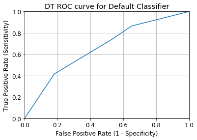

```python
fpr, tpr, thresholds = metrics.roc_curve(target_test, target_predicted_dt_prob[:, 1])
plt.plot(fpr, tpr)
plt.xlim([0.0, 1.0])
plt.ylim([0.0, 1.0])
plt.rcParams['font.size'] = 12
plt.title('DT ROC curve for Default Classifier')
plt.xlabel('False Positive Rate (1 - Specificity)')
plt.ylabel('True Positive Rate (Sensitivity)')
plt.grid(True)
```

```python
#verify DT with Cross Validation for Max Depth = 15
scores = cross_val_score(clf_dt, features_train, target_train, cv=5)
print("Cross Validation Score",scores)
scores.mean()
```

```
Cross Validation Score [0.6        0.71857143 0.70714286 0.74714286 0.61285714]
```

```
0.6771428571428573
```

## Random Forest

```python
# Random Forest N=10
from sklearn.ensemble import RandomForestClassifier
from sklearn.datasets import make_classification
rf = RandomForestClassifier(max_depth=4, random_state=0, n_estimators = 10)
rf_fit = rf.fit(features_train, target_train)
target_predicted_rf = rf_fit.predict(features_test)
print("RF Accuracy Score N=10", accuracy_score(target_test, target_predicted_rf))
print("Classification Report")
print(classification_report(target_test, target_predicted_rf))
print("Confusion Matrix")
print(confusion_matrix(target_test, target_predicted_rf))
print('Area under the ROC Curve')
target_predicted_rf_prob = rf.predict_proba(features_test)
roc_auc_score(target_test, target_predicted_rf_prob[:, 1])
```

```
RF Accuracy Score N=10 0.9191333333333334
Classification Report
             precision    recall  f1-score   support

          0       0.92      1.00      0.96     13787
          1       0.00      0.00      0.00      1213

avg / total       0.84      0.92      0.88     15000

Confusion Matrix
[[13787     0]
 [ 1213     0]]
Area under the ROC Curve
```

```
0.7082874227492822
```

```python
# Random Forest N=70, max depth = 10
from sklearn.ensemble import RandomForestClassifier
from sklearn.datasets import make_classification
rf = RandomForestClassifier(max_depth=10, random_state=0, n_estimators = 70)
rf_fit = rf.fit(features_train, target_train)
target_predicted_rf = rf_fit.predict(features_test)
print("RF Accuracy Score N=70, Max Depth = 10", accuracy_score(target_test, target_predicted_rf))
print("Classification Report")
print(classification_report(target_test, target_predicted_rf))
print("Confusion Matrix")
print(confusion_matrix(target_test, target_predicted_rf))
print('Area under the ROC Curve')
target_predicted_rf_prob = rf.predict_proba(features_test)
roc_auc_score(target_test, target_predicted_rf_prob[:, 1])
```

```
RF Accuracy Score N=70, Max Depth = 10 0.9191333333333334
Classification Report
             precision    recall  f1-score   support

          0       0.92      1.00      0.96     13787
          1       0.00      0.00      0.00      1213

avg / total       0.84      0.92      0.88     15000

Confusion Matrix
[[13787     0]
 [ 1213     0]]
Area under the ROC Curve
```

```
0.7230419637936283
```

```python
# Random Forest N=70, BEST MODEL
from sklearn.ensemble import RandomForestClassifier
from sklearn.datasets import make_classification
rf = RandomForestClassifier(max_depth=4, random_state=0, n_estimators = 70)
rf_fit = rf.fit(features_train, target_train)
target_predicted_rf = rf_fit.predict(features_test)
print("RF Accuracy Score N=70, Max Depth = 4", accuracy_score(target_test, target_predicted_rf))
print("Classification Report")
print(classification_report(target_test, target_predicted_rf))
print("Confusion Matrix")
print(confusion_matrix(target_test, target_predicted_rf))
print('Area under the ROC Curve')
target_predicted_rf_prob = rf.predict_proba(features_test)
roc_auc_score(target_test, target_predicted_rf_prob[:, 1])
```

[output not shown]

```
0.7314069663145305
```

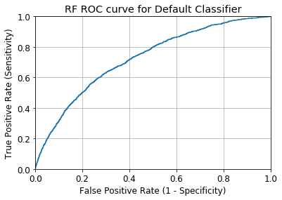

```python
fpr, tpr, thresholds = metrics.roc_curve(target_test, target_predicted_rf_prob[:, 1])
plt.plot(fpr, tpr)
plt.xlim([0.0, 1.0])
plt.ylim([0.0, 1.0])
plt.rcParams['font.size'] = 12
plt.title('RF ROC curve for Default Classifier')
plt.xlabel('False Positive Rate (1 - Specificity)')
plt.ylabel('True Positive Rate (Sensitivity)')
plt.grid(True)
```

```python
#verify RF with Cross Validation on N=10
scores = cross_val_score(rf_fit, features_train, target_train, cv=5)
print("Cross Validation Score",scores)
scores.mean()
```

```
Cross Validation Score [0.92285714 0.92285714 0.92285714 0.92285714 0.92285714]
```

```
0.9228571428571428
```

## Extra Trees

```python
from sklearn.ensemble import ExtraTreesClassifier
xdt = ExtraTreesClassifier(max_depth=3,
                         n_estimators=10,class_weight='balanced')
xdt2=xdt.fit(features_train, target_train)
predicted_xdt=xdt.predict(features_test)
expected = target_test
print("Extra Trees, MD = 3, N = 10, Weight = Balanced", accuracy_score(expected,predicted_xdt))
print(classification_report(expected, predicted_xdt,target_names=['No', 'Yes']))
print(confusion_matrix(expected, predicted_xdt))
print('Area under the ROC Curve')
target_predicted_xdt_prob = xdt.predict_proba(features_test)
roc_auc_score(target_test, target_predicted_xdt_prob[:, 1])
```

```
Extra Trees, MD = 3, N = 10, Weight = Balanced 0.6304666666666666
             precision    recall  f1-score   support

         No       0.95      0.63      0.76     13787
        Yes       0.13      0.66      0.22      1213

avg / total       0.89      0.63      0.71     15000

[[8660 5127]
 [ 416  797]]
Area under the ROC Curve
```

```
0.7016979745606681
```

```python
from sklearn.ensemble import ExtraTreesClassifier
xdt = ExtraTreesClassifier(max_depth=3,
                         n_estimators=50,class_weight=None)
xdt2=xdt.fit(features_train, target_train)
predicted_xdt=xdt.predict(features_test)
expected = target_test
print("Extra Trees, MD = 3, N = 50, Weight = None", accuracy_score(expected,predicted_xdt))
print(classification_report(expected, predicted_xdt,target_names=['No', 'Yes']))
print(confusion_matrix(expected, predicted_xdt))
print('Area under the ROC Curve')
target_predicted_xdt_prob = xdt.predict_proba(features_test)
roc_auc_score(target_test, target_predicted_xdt_prob[:, 1])
```

```
Extra Trees, MD = 3, N = 50, Weight = None 0.9191333333333334
             precision    recall  f1-score   support

         No       0.92      1.00      0.96     13787
        Yes       0.00      0.00      0.00      1213

avg / total       0.84      0.92      0.88     15000

[[13787     0]
 [ 1213     0]]
Area under the ROC Curve
```

```
0.7157605606103125
```

```python
#Best Model
from sklearn.ensemble import ExtraTreesClassifier
xdt = ExtraTreesClassifier(max_depth=5,
                         n_estimators=50,class_weight=None)
xdt2=xdt.fit(features_train, target_train)
predicted_xdt=xdt.predict(features_test)
expected = target_test
print("Extra Trees, MD = 3, N = 100, Weight = None", accuracy_score(expected,predicted_xdt))
print(classification_report(expected, predicted_xdt,target_names=['No', 'Yes']))
print(confusion_matrix(expected, predicted_xdt))
print('Area under the ROC Curve')
target_predicted_xdt_prob = xdt.predict_proba(features_test)
roc_auc_score(target_test, target_predicted_xdt_prob[:, 1])
```

[output not shown]

```
0.7337365457444688
```

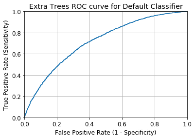

```python
fpr, tpr, thresholds = metrics.roc_curve(target_test, target_predicted_xdt_prob[:, 1])
plt.plot(fpr, tpr)
plt.xlim([0.0, 1.0])
plt.ylim([0.0, 1.0])
plt.rcParams['font.size'] = 12
plt.title('Extra Trees ROC curve for Default Classifier')
plt.xlabel('False Positive Rate (1 - Specificity)')
plt.ylabel('True Positive Rate (Sensitivity)')
plt.grid(True)
```

```python
#verify Extra Trees with Cross Validation max_depth = none, n_estimators = 100
scores = cross_val_score(xdt2, features_train, target_train, cv=10)
print("Cross Validation Score",scores)
scores.mean()
```

[output not shown]

```
0.9196285919790105
```

## Bagging

```python
from sklearn.ensemble import BaggingClassifier # base estimator is base learner algorithm.
from sklearn.neighbors import KNeighborsClassifier
clf_bag = BaggingClassifier(KNeighborsClassifier(), max_samples = 0.5, max_features=0.5)
clf_bag.fit(features_train, target_train)
predicted_bag=clf_bag.predict(features_test)
expected = target_test
print("Bagging Accuracy, KNN", accuracy_score(expected,predicted_bag))
print(classification_report(expected, predicted_bag,target_names=['No', 'Yes']))
print(confusion_matrix(expected, predicted_bag))
print('Area under the ROC Curve')
target_predicted_bag_prob = clf_bag.predict_proba(features_test)
roc_auc_score(target_test, target_predicted_bag_prob[:, 1])
```

```
Bagging Accuracy, KNN 0.9191333333333334
             precision    recall  f1-score   support

         No       0.92      1.00      0.96     13787
        Yes       0.00      0.00      0.00      1213

avg / total       0.84      0.92      0.88     15000

[[13787     0]
 [ 1213     0]]
Area under the ROC Curve
```

```
0.5735945142535136
```

```python
from sklearn.ensemble import BaggingClassifier # base estimator is base learner algorithm.
from sklearn.neighbors import KNeighborsClassifier
clf_bag = BaggingClassifier(KNeighborsClassifier(n_neighbors=5), max_samples = 0.5, max_features=0.5)
clf_bag.fit(features_train, target_train)
predicted_bag=clf_bag.predict(features_test)
expected = target_test
print("Bagging Accuracy, KNN, K=5", accuracy_score(expected,predicted_bag))
print(classification_report(expected, predicted_bag,target_names=['No', 'Yes']))
print(confusion_matrix(expected, predicted_bag))
print('Area under the ROC Curve')
target_predicted_bag_prob = clf_bag.predict_proba(features_test)
roc_auc_score(target_test, target_predicted_bag_prob[:, 1])
```

```
Bagging Accuracy, KNN, K=5 0.9191333333333334
             precision    recall  f1-score   support

         No       0.92      1.00      0.96     13787
        Yes       0.00      0.00      0.00      1213

avg / total       0.84      0.92      0.88     15000

[[13787     0]
 [ 1213     0]]
Area under the ROC Curve
```

```
0.5788315348502966
```

```python
# BEST MODEL
from sklearn.ensemble import BaggingClassifier # base estimator is base learner algorithm.
from sklearn.neighbors import KNeighborsClassifier
clf_bag = BaggingClassifier(DecisionTreeClassifier(), max_samples = 0.2, max_features=0.8, n_estimators = 70)
clf_bag.fit(features_train, target_train)
predicted_bag=clf_bag.predict(features_test)
expected = target_test
print("Bagging Accuracy, Decision Tree (Default) N Estimators = 70", accuracy_score(expected,predicted_bag))
print(classification_report(expected, predicted_bag,target_names=['No', 'Yes']))
print(confusion_matrix(expected, predicted_bag))
print('Area under the ROC Curve')
target_predicted_bag_prob = clf_bag.predict_proba(features_test)
roc_auc_score(target_test, target_predicted_bag_prob[:, 1])
```

```
Bagging Accuracy, Decision Tree (Default) N Estimators = 70 0.9191333333333334
             precision    recall  f1-score   support

         No       0.92      1.00      0.96     13787
        Yes       0.50      0.00      0.00      1213

avg / total       0.89      0.92      0.88     15000

[[13786     1]
 [ 1212     1]]
Area under the ROC Curve
```

```
0.6831136133056273
```

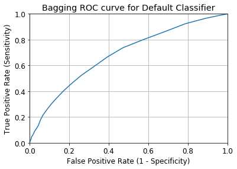

```python
fpr, tpr, thresholds = metrics.roc_curve(target_test, target_predicted_bag_prob[:, 1])
plt.plot(fpr, tpr)
plt.xlim([0.0, 1.0])
plt.ylim([0.0, 1.0])
plt.rcParams['font.size'] = 12
plt.title('Bagging ROC curve for Default Classifier')
plt.xlabel('False Positive Rate (1 - Specificity)')
plt.ylabel('True Positive Rate (Sensitivity)')
plt.grid(True)
```

```python
#verify Bagging with Cross Validation #DT Method
scores = cross_val_score(clf_bag, features_train, target_train, cv=10)
print("Cross Validation Score",scores)
scores.mean()
```

```
Cross Validation Score [0.92285714 0.92285714 0.92285714 0.92285714 0.92285714 0.92285714
 0.92285714 0.92285714 0.92285714 0.92285714]
```

```
0.9228571428571429
```

## Adaboost

```python
from sklearn.ensemble import AdaBoostClassifier
from sklearn.tree import DecisionTreeClassifier
import time
start_time = time.clock()
bdt = AdaBoostClassifier(DecisionTreeClassifier(max_depth=3),
                         algorithm="SAMME",
                         n_estimators=200)
bdt.fit(features_train, target_train)
predicted_bdt=bdt.predict(features_test)
expected = target_test
print(time.clock() - start_time, "seconds")
print("Adaboost Accuracy, DT, MD = 3, N = 200, Algorithm = SAMME", accuracy_score(expected,predicted_bdt))
print(classification_report(expected, predicted_bdt,target_names=['No', 'Yes']))
print(confusion_matrix(expected, predicted_bdt))
print('Area under the ROC Curve')
target_predicted_bdt_prob = bdt.predict_proba(features_test)
roc_auc_score(target_test, target_predicted_bdt_prob[:, 1])
```

```
28.53731199999993 seconds
Adaboost Accuracy, DT, MD = 3, N = 200, Algorithm = SAMME 0.9188666666666667
             precision    recall  f1-score   support

         No       0.92      1.00      0.96     13787
        Yes       0.44      0.01      0.02      1213

avg / total       0.88      0.92      0.88     15000

[[13768    19]
 [ 1198    15]]
Area under the ROC Curve
```

```
0.7168785893446227
```

```python
from sklearn.ensemble import AdaBoostClassifier
from sklearn.tree import DecisionTreeClassifier
import time
start_time = time.clock()
bdt = AdaBoostClassifier(RandomForestClassifier(max_depth=3),
                         algorithm="SAMME",
                         n_estimators=100)
bdt.fit(features_train, target_train)
predicted_bdt=bdt.predict(features_test)
expected = target_test
print(time.clock() - start_time, "seconds")
print("Adaboost Accuracy, RF, MD = 3, N = 100, Algorithm = SAMME", accuracy_score(expected,predicted_bdt))
print(classification_report(expected, predicted_bdt,target_names=['No', 'Yes']))
print(confusion_matrix(expected, predicted_bdt))
print('Area under the ROC Curve')
target_predicted_bdt_prob = bdt.predict_proba(features_test)
roc_auc_score(target_test, target_predicted_bdt_prob[:, 1])
```

[output not shown]

```
0.6750112118796093
```

```python
import time
start_time = time.clock()
bdt = AdaBoostClassifier(RandomForestClassifier(max_depth=3),
                         algorithm="SAMME.R", learning_rate = 0.7,
                         n_estimators=10)
bdt.fit(features_train, target_train)
predicted_bdt=bdt.predict(features_test)
expected = target_test
print(time.clock() - start_time, "seconds")
print("Adaboost Accuracy, RF, MD = 3, N = 10, Algorithm = SAMME.R, Learning Rate = 0.7", accuracy_score(expected,predicted_bdt))
print(classification_report(expected, predicted_bdt,target_names=['No', 'Yes']))
print(confusion_matrix(expected, predicted_bdt))
print('Area under the ROC Curve')
target_predicted_bdt_prob = bdt.predict_proba(features_test)
roc_auc_score(target_test, target_predicted_bdt_prob[:, 1])
```

[output not shown]

```
0.7214844528602751
```

```python
# BEST MODEL
import time
start_time = time.clock()
bdt = AdaBoostClassifier(RandomForestClassifier(max_depth=8),
                         algorithm="SAMME.R", learning_rate = 0.1,
                         n_estimators=10)
bdt.fit(features_train, target_train)
predicted_bdt=bdt.predict(features_test)
expected = target_test
print(time.clock() - start_time, "seconds")
print("Adaboost Accuracy, RF, MD = 8, N = 10, Algorithm = SAMME.R, Learning Rate = 0.1", accuracy_score(expected,predicted_bdt))
print(classification_report(expected, predicted_bdt,target_names=['No', 'Yes']))
print(confusion_matrix(expected, predicted_bdt))
print('Area under the ROC Curve')
target_predicted_bdt_prob = bdt.predict_proba(features_test)
roc_auc_score(target_test, target_predicted_bdt_prob[:, 1])
```

```
6.7712269999999535 seconds
Adaboost Accuracy, RF, MD = 8, N = 10, Algorithm = SAMME.R, Learning Rate = 0.1 0.9191333333333334
             precision    recall  f1-score   support

         No       0.92      1.00      0.96     13787
        Yes       0.00      0.00      0.00      1213

avg / total       0.84      0.92      0.88     15000

[[13787     0]
 [ 1213     0]]
Area under the ROC Curve
```

```
0.7326272625843037
```

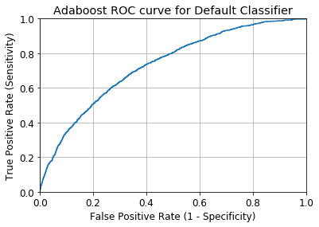

```python
fpr, tpr, thresholds = metrics.roc_curve(target_test, target_predicted_bdt_prob[:, 1])
plt.plot(fpr, tpr)
plt.xlim([0.0, 1.0])
plt.ylim([0.0, 1.0])
plt.rcParams['font.size'] = 12
plt.title('Adaboost ROC curve for Default Classifier')
plt.xlabel('False Positive Rate (1 - Specificity)')
plt.ylabel('True Positive Rate (Sensitivity)')
plt.grid(True)
```

```python
#verify AdaBoost with Cross Validation
scores = cross_val_score(bdt, features_train, target_train, cv=10)
print("Cross Validation Score",scores)
scores.mean()
```

```
Cross Validation Score [0.91945159 0.91945159 0.91945159 0.91971429 0.91971429 0.91971429
 0.91971429 0.91969134 0.91969134 0.91969134]
```

```
0.9196285919790105
```

## SVM Linear - Probability Function not Built in.

```python
# Linear Scaling of Data
from sklearn.preprocessing import StandardScaler
scaler = StandardScaler()
# Fit only to the training data
scaler.fit(features_train)
# Now apply the transformations to the data:
X_train = scaler.transform(features_train)
X_test = scaler.transform(features_test)
```

```python
from sklearn.svm import LinearSVC
import time
start_time = time.clock()
clf_linSVC=LinearSVC(penalty='l2', loss='hinge', dual=True, tol=0.0001, C=0.1, class_weight='balanced', max_iter = 100)
clf_linSVC.fit(X_train, target_train)
predicted_SVC=clf_linSVC.predict(X_test)
expected = target_test
print(time.clock() - start_time, "seconds")
print('C=0.1')
print(classification_report(expected, predicted_SVC,target_names=['No', 'Yes']))
print(confusion_matrix(expected, predicted_SVC))
print(accuracy_score(expected,predicted_SVC))
#print('Area under the ROC Curve')
#target_predicted_clf_linSVC_prob = clf_linSVC.predict_proba(X_test)
#roc_auc_score(target_test, target_predicted_clf_linSVC_prob[:, 1])
```

```
0.04033500000002732 seconds
C=0.1
             precision    recall  f1-score   support

         No       0.96      0.68      0.80      1384
        Yes       0.15      0.67      0.25       116

avg / total       0.90      0.68      0.76      1500

[[945 439]
 [ 38  78]]
0.682
```

```python
# BEST MODEL
import time
start_time = time.clock()
clf_linSVC=LinearSVC(penalty='l2', loss='squared_hinge', dual=True, tol=0.0001, C=0.1, class_weight='balanced', max_iter = 100)
clf_linSVC.fit(X_train, target_train)
predicted_SVC=clf_linSVC.predict(X_test)
expected = target_test
print(time.clock() - start_time, "seconds")
print('C=0.1')
print(classification_report(expected, predicted_SVC,target_names=['No', 'Yes']))
print(confusion_matrix(expected, predicted_SVC))
print(accuracy_score(expected,predicted_SVC))
```

```
1.27289299999984 seconds
C=0.1
             precision    recall  f1-score   support

         No       0.96      0.68      0.80     13787
        Yes       0.15      0.65      0.25      1213

avg / total       0.89      0.68      0.75     15000

[[9396 4391]
 [ 429  784]]
0.6786666666666666
```

```python
import time
start_time = time.clock()
clf_linSVC=LinearSVC(penalty='l2', loss='squared_hinge', dual=False, tol=0.0001, C=0.1, class_weight='balanced', max_iter = 100)
clf_linSVC.fit(X_train, target_train)
predicted_SVC=clf_linSVC.predict(X_test)
expected = target_test
print(time.clock() - start_time, "seconds")
print('C=0.1')
print(classification_report(expected, predicted_SVC,target_names=['No', 'Yes']))
print(confusion_matrix(expected, predicted_SVC))
print(accuracy_score(expected,predicted_SVC))
```

```
0.03899699999999484 seconds
C=0.1
             precision    recall  f1-score   support

         No       0.96      0.70      0.81      1384
        Yes       0.15      0.66      0.25       116

avg / total       0.90      0.69      0.76      1500

[[965 419]
 [ 40  76]]
0.694
```

```python
import time
start_time = time.clock()
clf_linSVC=LinearSVC(penalty='l2', loss='squared_hinge', dual=True, tol=0.001, C=0.1, class_weight='balanced'
                     , max_iter = 500)
clf_linSVC.fit(X_train, target_train)
predicted_SVC=clf_linSVC.predict(X_test)
expected = target_test
print(time.clock() - start_time, "seconds")
print('C=0.1')
print(classification_report(expected, predicted_SVC,target_names=['No', 'Yes']))
print(confusion_matrix(expected, predicted_SVC))
print(accuracy_score(expected,predicted_SVC))
```

```
0.2654619999999568 seconds
C=0.1
             precision    recall  f1-score   support

         No       0.96      0.70      0.81      1384
        Yes       0.15      0.66      0.25       116

avg / total       0.90      0.69      0.76      1500

[[964 420]
 [ 40  76]]
0.6933333333333334
```

```python
from sklearn.calibration import CalibratedClassifierCV
clf_proba = CalibratedClassifierCV(clf_linSVC)
clf_proba.fit(X_train, target_train)
target_predicted_lin_svm_prob = clf_proba.predict_proba(X_test)
roc_auc_score(target_test, target_predicted_lin_svm_prob[:, 1])
```

```
0.7205222956665331
```

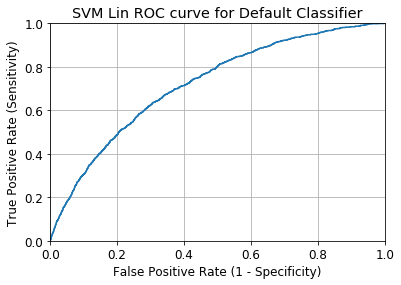

```python
fpr, tpr, thresholds = metrics.roc_curve(target_test, target_predicted_lin_svm_prob[:, 1])
plt.plot(fpr, tpr)
plt.xlim([0.0, 1.0])
plt.ylim([0.0, 1.0])
plt.rcParams['font.size'] = 12
plt.title('SVM Lin ROC curve for Default Classifier')
plt.xlabel('False Positive Rate (1 - Specificity)')
plt.ylabel('True Positive Rate (Sensitivity)')
plt.grid(True)
```

```python
#verify SVM Linear with Cross Validation C = 0.5
scores = cross_val_score(clf_linSVC, X_train, target_train, cv=10)
print("Cross Validation Score",scores)
scores.mean()
```

```
Cross Validation Score [0.68571429 0.70285714 0.70571429 0.68857143 0.70285714 0.69714286
 0.67714286 0.66857143 0.67428571 0.64571429]
```

```
0.6848571428571428
```

## Gradient Boosting

```python
from sklearn.ensemble import GradientBoostingClassifier
import time
start_time = time.clock()
clf_GBC = GradientBoostingClassifier(n_estimators=100, learning_rate=1.7, max_depth=1, random_state=0)
clf_GBC.fit(features_train, target_train)
predicted_GBC=clf_GBC.predict(features_test)
expected = target_test
print(time.clock() - start_time, "seconds")
print("Gradient Boost Accuracy", accuracy_score(expected,predicted_GBC))
print(classification_report(expected, predicted_GBC,target_names=['No', 'Yes']))
print(confusion_matrix(expected, predicted_GBC))
print('Area under the ROC Curve')
target_predicted_clf_GBC_prob = clf_GBC.predict_proba(features_test)
roc_auc_score(target_test, target_predicted_clf_GBC_prob[:, 1])
```

```
0.18694800000002942 seconds
Gradient Boost Accuracy 0.9226666666666666
             precision    recall  f1-score   support

         No       0.92      1.00      0.96      1384
        Yes       0.50      0.01      0.02       116

avg / total       0.89      0.92      0.89      1500

[[1383    1]
 [ 115    1]]
Area under the ROC Curve
```

```
0.6847562039067172
```

```python
# BEST MODEL
from sklearn.ensemble import GradientBoostingClassifier
import time
start_time = time.clock()
clf_GBC = GradientBoostingClassifier(n_estimators=200, learning_rate=0.7, max_depth=1, random_state=0, criterion = "mse")
clf_GBC.fit(features_train, target_train)
predicted_GBC=clf_GBC.predict(features_test)
expected = target_test
print(time.clock() - start_time, "seconds")
print("Gradient Boost Accuracy", accuracy_score(expected,predicted_GBC))
print(classification_report(expected, predicted_GBC,target_names=['No', 'Yes']))
print(confusion_matrix(expected, predicted_GBC))
print('Area under the ROC Curve')
target_predicted_clf_GBC_prob = clf_GBC.predict_proba(features_test)
roc_auc_score(target_test, target_predicted_clf_GBC_prob[:, 1])
```

```
5.404833000000053 seconds
Gradient Boost Accuracy 0.9185333333333333
             precision    recall  f1-score   support

         No       0.92      1.00      0.96     13787
        Yes       0.40      0.01      0.03      1213

avg / total       0.88      0.92      0.88     15000

[[13760    27]
 [ 1195    18]]
Area under the ROC Curve
```

```
0.741244470175167
```

```python
from sklearn.ensemble import GradientBoostingClassifier
import time
start_time = time.clock()
clf_GBC = GradientBoostingClassifier(n_estimators=200, learning_rate=0.7, max_depth=10, random_state=0, criterion = "mse")
clf_GBC.fit(features_train, target_train)
predicted_GBC=clf_GBC.predict(features_test)
expected = target_test
print(time.clock() - start_time, "seconds")
print("Gradient Boost Accuracy", accuracy_score(expected,predicted_GBC))
print(classification_report(expected, predicted_GBC,target_names=['No', 'Yes']))
print(confusion_matrix(expected, predicted_GBC))
print('Area under the ROC Curve')
target_predicted_clf_GBC_prob = clf_GBC.predict_proba(features_test)
roc_auc_score(target_test, target_predicted_clf_GBC_prob[:, 1])
```

```
78.9741939999999 seconds
Gradient Boost Accuracy 0.8979333333333334
             precision    recall  f1-score   support

         No       0.92      0.97      0.95     13787
        Yes       0.16      0.06      0.09      1213

avg / total       0.86      0.90      0.88     15000

[[13394   393]
 [ 1138    75]]
Area under the ROC Curve
```

```
0.6593231457929203
```

```python
from sklearn.ensemble import GradientBoostingClassifier
import time
start_time = time.clock()
clf_GBC = GradientBoostingClassifier(n_estimators=200, learning_rate=0.7, max_depth=3, random_state=0, criterion = "mse")
clf_GBC.fit(features_train, target_train)
predicted_GBC=clf_GBC.predict(features_test)
expected = target_test
print(time.clock() - start_time, "seconds")
print("Gradient Boost Accuracy", accuracy_score(expected,predicted_GBC))
print(classification_report(expected, predicted_GBC,target_names=['No', 'Yes']))
print(confusion_matrix(expected, predicted_GBC))
print('Area under the ROC Curve')
target_predicted_clf_GBC_prob = clf_GBC.predict_proba(features_test)
roc_auc_score(target_test, target_predicted_clf_GBC_prob[:, 1])
```

```
1.2540659999999662 seconds
Gradient Boost Accuracy 0.9013333333333333
             precision    recall  f1-score   support

         No       0.92      0.97      0.95      1384
        Yes       0.14      0.05      0.07       116

avg / total       0.86      0.90      0.88      1500

[[1346   38]
 [ 110    6]]
Area under the ROC Curve
```

```
0.6497221945385689
```

[figure not shown]

```python
fpr, tpr, thresholds = metrics.roc_curve(target_test, target_predicted_clf_GBC_prob[:, 1])
plt.plot(fpr, tpr)
plt.xlim([0.0, 1.0])
plt.ylim([0.0, 1.0])
plt.rcParams['font.size'] = 12
plt.title('GBC ROC curve for Default Classifier')
plt.xlabel('False Positive Rate (1 - Specificity)')
plt.ylabel('True Positive Rate (Sensitivity)')
plt.grid(True)
```

```python
#verify Gradient Boosting with Cross Validation
scores = cross_val_score(clf_GBC, features_train, target_train, cv=10)
print("Cross Validation Score",scores)
scores.mean()
```

```
Cross Validation Score [0.91859469 0.91859469 0.91973722 0.92114286 0.92028571 0.91971429
 0.91885714 0.91911975 0.92054873 0.91940554]
```

```
0.919600061355107
```

## SGD

```python
from sklearn.preprocessing import StandardScaler
scaler = StandardScaler()
# Fit only to the training data
scaler.fit(features_train)
# Now apply the transformations to the data:
X_train = scaler.transform(features_train)
X_test = scaler.transform(features_test)
```

```python
from sklearn.linear_model import SGDClassifier
import time
start_time = time.clock()
clf_sgd = SGDClassifier(alpha=0.0001, average=False, class_weight=None, epsilon=0.1,
       eta0=0.0, fit_intercept=True, l1_ratio=0.15,
       learning_rate='optimal', loss='hinge', max_iter=None, n_iter=None,
       n_jobs=1, penalty='l2', power_t=0.5, random_state=None,
       shuffle=True, tol=None, verbose=0, warm_start=False)
clf_sgd = clf_sgd.fit(X_train, target_train)
target_predicted_sgd = clf_sgd.predict(X_test)
print(time.clock() - start_time, "seconds")
print("SGD Accuracy Score", accuracy_score(target_test, target_predicted_sgd))
print("Classification Report")
print(classification_report(target_test, target_predicted_sgd))
print("Confusion Matrix")
print(confusion_matrix(target_test, target_predicted_sgd))
print('Area under the ROC Curve')
from sklearn.calibration import CalibratedClassifierCV
clf_proba = CalibratedClassifierCV(clf_sgd)
clf_proba.fit(X_train, target_train)
target_predicted_sgd_prob = clf_proba.predict_proba(X_test)
roc_auc_score(target_test, target_predicted_sgd_prob[:, 1])
```

```
0.008760999999935848 seconds
SGD Accuracy Score 0.8473333333333334
Classification Report
             precision    recall  f1-score   support

          0       0.92      0.91      0.92      1384
          1       0.07      0.08      0.07       116

avg / total       0.86      0.85      0.85      1500

Confusion Matrix
[[1262  122]
 [ 107    9]]
Area under the ROC Curve
```

```
0.5889039764799681
```

```python
import time
start_time = time.clock()
clf_sgd = SGDClassifier(alpha=0.0001, average=False, class_weight="balanced", epsilon=0.1,
       eta0=0.0, fit_intercept=True, l1_ratio=0.15,
       learning_rate='optimal', loss='hinge', max_iter=None, n_iter=None,
       n_jobs=1, penalty='l2', power_t=0.5, random_state=None,
       shuffle=True, tol=None, verbose=0, warm_start=False)
clf_sgd = clf_sgd.fit(X_train, target_train)
target_predicted_sgd = clf_sgd.predict(X_test)
print(time.clock() - start_time, "seconds")
print("SGD Accuracy Score", accuracy_score(target_test, target_predicted_sgd))
print("Classification Report")
print(classification_report(target_test, target_predicted_sgd))
print("Confusion Matrix")
print(confusion_matrix(target_test, target_predicted_sgd))
print('Area under the ROC Curve')
from sklearn.calibration import CalibratedClassifierCV
clf_proba = CalibratedClassifierCV(clf_sgd)
clf_proba.fit(X_train, target_train)
target_predicted_sgd_prob = clf_proba.predict_proba(X_test)
roc_auc_score(target_test, target_predicted_sgd_prob[:, 1])
```

```
0.00947499999995216 seconds
SGD Accuracy Score 0.6133333333333333
Classification Report
             precision    recall  f1-score   support

          0       0.95      0.61      0.74      1384
          1       0.12      0.63      0.20       116

avg / total       0.89      0.61      0.70      1500

Confusion Matrix
[[847 537]
 [ 43  73]]
Area under the ROC Curve
```

```
0.64703134343233
```

```python
# BEST MODEL
import time
start_time = time.clock()
clf_sgd = SGDClassifier(alpha=0.0001, average=False, class_weight="balanced", epsilon=0.5,
       eta0=0.0, fit_intercept=True, l1_ratio=0.3,
       learning_rate='optimal', loss='hinge', max_iter=None, n_iter=None,
       n_jobs=1, penalty='l2', power_t=0.5, random_state=None,
       shuffle=True, tol=None, verbose=0, warm_start=False)
clf_sgd = clf_sgd.fit(X_train, target_train)
target_predicted_sgd = clf_sgd.predict(X_test)
print(time.clock() - start_time, "seconds")
print("SGD Accuracy Score", accuracy_score(target_test, target_predicted_sgd))
print("Classification Report")
print(classification_report(target_test, target_predicted_sgd))
print("Confusion Matrix")
print(confusion_matrix(target_test, target_predicted_sgd))
print('Area under the ROC Curve')
from sklearn.calibration import CalibratedClassifierCV
clf_proba = CalibratedClassifierCV(clf_sgd)
clf_proba.fit(X_train, target_train)
target_predicted_sgd_prob = clf_proba.predict_proba(X_test)
roc_auc_score(target_test, target_predicted_sgd_prob[:, 1])
```

```
0.05889100000013059 seconds
SGD Accuracy Score 0.5575333333333333
Classification Report
             precision    recall  f1-score   support

          0       0.94      0.55      0.70     13787
          1       0.11      0.63      0.19      1213

avg / total       0.88      0.56      0.65     15000

Confusion Matrix
[[7600 6187]
 [ 450  763]]
Area under the ROC Curve
```

```
0.6456527293624212
```

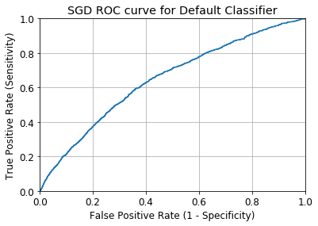

```python
fpr, tpr, thresholds = metrics.roc_curve(target_test, target_predicted_sgd_prob[:, 1])
plt.plot(fpr, tpr)
plt.xlim([0.0, 1.0])
plt.ylim([0.0, 1.0])
plt.rcParams['font.size'] = 12
plt.title('SGD ROC curve for Default Classifier')
plt.xlabel('False Positive Rate (1 - Specificity)')
plt.ylabel('True Positive Rate (Sensitivity)')
plt.grid(True)
```

```python
#verify SGD with Cross Validation
scores = cross_val_score(clf_sgd, X_train, target_train, cv=10)
print("Cross Validation Score",scores)
scores.mean()
```

```
Cross Validation Score [0.51899457 0.66352471 0.6809483  0.54657143 0.58171429 0.56342857
 0.51571429 0.63475279 0.57959417 0.60903115]
```

```
0.5894274260150668
```

Unstable model, do not put SGD into production.

## Artificial Neural Network

```python
from sklearn.preprocessing import StandardScaler
scaler = StandardScaler()
# Fit only to the training data
scaler.fit(features_train)
# Now apply the transformations to the data:
X_train = scaler.transform(features_train)
X_test = scaler.transform(features_test)
```

```python
from sklearn.neural_network import MLPClassifier
mlp = MLPClassifier(hidden_layer_sizes=(10,5))
mlp.fit(X_train,target_train)
predictions = mlp.predict(X_test)
from sklearn.metrics import classification_report,confusion_matrix
print("Accuracy", accuracy_score(target_test,predictions))
print(classification_report(target_test,predictions))
print(confusion_matrix(target_test,predictions))
print('Area under the ROC Curve')
target_predicted_mlp_prob = mlp.predict_proba(X_test)
roc_auc_score(target_test, target_predicted_mlp_prob[:, 1])
```

```
Accuracy 0.9193333333333333
             precision    recall  f1-score   support

          0       0.93      0.99      0.96      1384
          1       0.37      0.06      0.10       116

avg / total       0.88      0.92      0.89      1500

[[1372   12]
 [ 109    7]]
Area under the ROC Curve
```

```
0.6677920071756028
```

```python
from sklearn.neural_network import MLPClassifier
mlp = MLPClassifier(hidden_layer_sizes=(10,6,5))
mlp.fit(X_train,target_train)
predictions = mlp.predict(X_test)
from sklearn.metrics import classification_report,confusion_matrix
print("Accuracy", accuracy_score(target_test,predictions))
print(classification_report(target_test,predictions))
print(confusion_matrix(target_test,predictions))
print('Area under the ROC Curve')
target_predicted_mlp_prob = mlp.predict_proba(X_test)
roc_auc_score(target_test, target_predicted_mlp_prob[:, 1])
```

```
Accuracy 0.9066666666666666
             precision    recall  f1-score   support

          0       0.92      0.98      0.95      1384
          1       0.12      0.03      0.05       116

avg / total       0.86      0.91      0.88      1500

[[1356   28]
 [ 112    4]]
Area under the ROC Curve
```

```
0.6523133844927247
```

```python
from sklearn.neural_network import MLPClassifier
mlp = MLPClassifier(hidden_layer_sizes=(5,2))
mlp.fit(X_train,target_train)
predictions = mlp.predict(X_test)
from sklearn.metrics import classification_report,confusion_matrix
print("Accuracy", accuracy_score(target_test,predictions))
print(classification_report(target_test,predictions))
print(confusion_matrix(target_test,predictions))
print('Area under the ROC Curve')
target_predicted_mlp_prob = mlp.predict_proba(X_test)
roc_auc_score(target_test, target_predicted_mlp_prob[:, 1])
```

```
Accuracy 0.9226666666666666
             precision    recall  f1-score   support

          0       0.92      1.00      0.96      1384
          1       0.00      0.00      0.00       116

avg / total       0.85      0.92      0.89      1500

[[1384    0]
 [ 116    0]]
Area under the ROC Curve
```

```
0.6476043950568069
```

```python
from sklearn.neural_network import MLPClassifier
mlp = MLPClassifier(hidden_layer_sizes=(10,5), activation = "logistic")
mlp.fit(X_train,target_train)
predictions = mlp.predict(X_test)
from sklearn.metrics import classification_report,confusion_matrix
print("Accuracy", accuracy_score(target_test,predictions))
print(classification_report(target_test,predictions))
print(confusion_matrix(target_test,predictions))
print('Area under the ROC Curve')
target_predicted_mlp_prob = mlp.predict_proba(X_test)
roc_auc_score(target_test, target_predicted_mlp_prob[:, 1])
```

```
Accuracy 0.9226666666666666
             precision    recall  f1-score   support

          0       0.92      1.00      0.96      1384
          1       0.00      0.00      0.00       116

avg / total       0.85      0.92      0.89      1500

[[1384    0]
 [ 116    0]]
Area under the ROC Curve
```

```
0.7131316025513255
```

```python
from sklearn.neural_network import MLPClassifier
mlp = MLPClassifier(hidden_layer_sizes=(10,5), activation = "identity")
mlp.fit(X_train,target_train)
predictions = mlp.predict(X_test)
from sklearn.metrics import classification_report,confusion_matrix
print("Accuracy", accuracy_score(target_test,predictions))
print(classification_report(target_test,predictions))
print(confusion_matrix(target_test,predictions))
print('Area under the ROC Curve')
target_predicted_mlp_prob = mlp.predict_proba(X_test)
roc_auc_score(target_test, target_predicted_mlp_prob[:, 1])
```

```
Accuracy 0.924
             precision    recall  f1-score   support

          0       0.92      1.00      0.96      1384
          1       1.00      0.02      0.03       116

avg / total       0.93      0.92      0.89      1500

[[1384    0]
 [ 114    2]]
Area under the ROC Curve
```

```
0.7203258919673111
```

```python
# BEST MODEL
from sklearn.neural_network import MLPClassifier
mlp = MLPClassifier(hidden_layer_sizes=(10,5), activation = "identity", solver = "sgd")
mlp.fit(X_train,target_train)
predictions = mlp.predict(X_test)
from sklearn.metrics import classification_report,confusion_matrix
print("Accuracy", accuracy_score(target_test,predictions))
print(classification_report(target_test,predictions))
print(confusion_matrix(target_test,predictions))
print('Area under the ROC Curve')
target_predicted_mlp_prob = mlp.predict_proba(X_test)
roc_auc_score(target_test, target_predicted_mlp_prob[:, 1])
```

```
Accuracy 0.919
             precision    recall  f1-score   support

          0       0.92      1.00      0.96     13787
          1       0.00      0.00      0.00      1213

avg / total       0.84      0.92      0.88     15000

[[13785     2]
 [ 1213     0]]
Area under the ROC Curve
```

```
0.7171080251651093
```

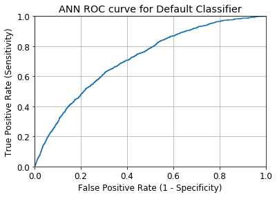

```python
fpr, tpr, thresholds = metrics.roc_curve(target_test, target_predicted_mlp_prob[:, 1])
plt.plot(fpr, tpr)
plt.xlim([0.0, 1.0])
plt.ylim([0.0, 1.0])
plt.rcParams['font.size'] = 12
plt.title('ANN ROC curve for Default Classifier')
plt.xlabel('False Positive Rate (1 - Specificity)')
plt.ylabel('True Positive Rate (Sensitivity)')
plt.grid(True)
```

```python
#verify ANN with Cross Validation Hidden 10,5 layers
scores = cross_val_score(mlp, X_train, target_train, cv=5)
print("Cross Validation Score",scores)
scores.mean()
```

```
Cross Validation Score [0.92285714 0.92285714 0.92285714 0.92142857 0.92285714]
```

```
0.9225714285714286
```

## XG Boost

```python
## Installed XGBoost from https://xgboost.readthedocs.io/en/latest/build.html
import xgboost as xgb
from sklearn.metrics import accuracy_score, make_scorer
from sklearn.model_selection import cross_validate
xgb = xgb.XGBClassifier(max_depth=3, random_state=314, seed=314, silent=True)
xgb_score = xgb.fit(features_train, target_train)
predicted_xgb = xgb.predict(features_test)
expected = target_test
print("XG Boost", accuracy_score(expected,predicted_xgb))
print(classification_report(expected, predicted_xgb,target_names=['No', 'Yes']))
print(confusion_matrix(expected, predicted_xgb))
print('Area under the ROC Curve')
target_predicted_xgb_prob = xgb.predict_proba(features_test)
roc_auc_score(target_test, target_predicted_xgb_prob[:, 1])
```

```
XG Boost 0.9233333333333333
             precision    recall  f1-score   support

         No       0.92      1.00      0.96      1384
        Yes       0.67      0.02      0.03       116

avg / total       0.90      0.92      0.89      1500

[[1383    1]
 [ 114    2]]
Area under the ROC Curve
```

```
0.7126955850109626
```

```python
import xgboost as xgb
from sklearn.metrics import accuracy_score, make_scorer
from sklearn.model_selection import cross_validate
xgb = xgb.XGBClassifier(max_depth=1, random_state=500, seed=314, silent=True, learning_rate=0.3)
xgb_score = xgb.fit(features_train, target_train)
predicted_xgb = xgb.predict(features_test)
expected = target_test
print("XG Boost", accuracy_score(expected,predicted_xgb))
print(classification_report(expected, predicted_xgb,target_names=['No', 'Yes']))
print(confusion_matrix(expected, predicted_xgb))
print('Area under the ROC Curve')
target_predicted_xgb_prob = xgb.predict_proba(features_test)
roc_auc_score(target_test, target_predicted_xgb_prob[:, 1])
```

```
XG Boost 0.9226666666666666
             precision    recall  f1-score   support

         No       0.92      1.00      0.96      1384
        Yes       0.00      0.00      0.00       116

avg / total       0.85      0.92      0.89      1500

[[1384    0]
 [ 116    0]]
Area under the ROC Curve
```

```
0.7250411102252342
```

```python
# Best Model
import xgboost as xgb
from sklearn.metrics import accuracy_score, make_scorer
from sklearn.model_selection import cross_validate
xgb = xgb.XGBClassifier(max_depth=1, random_state=500, seed=314, silent=True, learning_rate=0.3, objective="binary:logistic")
xgb_score = xgb.fit(features_train, target_train)
predicted_xgb = xgb.predict(features_test)
expected = target_test
print("XG Boost", accuracy_score(expected,predicted_xgb))
print(classification_report(expected, predicted_xgb,target_names=['No', 'Yes']))
print(confusion_matrix(expected, predicted_xgb))
print('Area under the ROC Curve')
target_predicted_xgb_prob = xgb.predict_proba(features_test)
roc_auc_score(target_test, target_predicted_xgb_prob[:, 1])
```

```
XG Boost 0.9191333333333334
             precision    recall  f1-score   support

         No       0.92      1.00      0.96     13787
        Yes       0.00      0.00      0.00      1213

avg / total       0.84      0.92      0.88     15000

[[13787     0]
 [ 1213     0]]
Area under the ROC Curve
```

```
0.7370596134296434
```

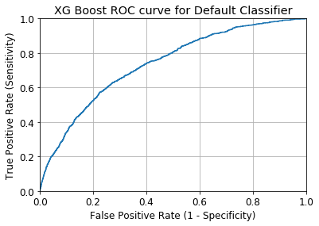

```python
fpr, tpr, thresholds = metrics.roc_curve(target_test, target_predicted_xgb_prob[:, 1])
plt.plot(fpr, tpr)
plt.xlim([0.0, 1.0])
plt.ylim([0.0, 1.0])
plt.rcParams['font.size'] = 12
plt.title('XG Boost ROC curve for Default Classifier')
plt.xlabel('False Positive Rate (1 - Specificity)')
plt.ylabel('True Positive Rate (Sensitivity)')
plt.grid(True)
```

```python
#verify XG Boost with Cross Validation
scores = cross_val_score(xgb, features_train, target_train, cv=5)
print("Cross Validation Score",scores)
scores.mean()
```

```
Cross Validation Score [0.92428571 0.92142857 0.92285714 0.92428571 0.92285714]
```

```
0.9231428571428572
```

## Light GBM (Not Working)

Light GBM is leading a lot of the top competitors I believe. After researching it, it has similar interest as XGBOOST. Sadly Light GBM does not work on the latest version of Python, because all of this was mostly written, I did not want to risk uninstalling just for one more model to work. However, now that this is turned in I will tinker and try and solve the problem to have a shot at the top of the leaderboard.

```python
## Installed LightGBM from https://lightgbm.readthedocs.io/en/latest/Installation-Guide.html
## Possible FIX: https://github.com/Microsoft/LightGBM/issues/1369
import lightgbm as lgb

from sklearn.metrics import accuracy_score, make_scorer
from sklearn.model_selection import cross_validate

lightgbm.LGBMModel

lgb = lgb.LGBMModel(max_depth=3, random_state=314, seed=314, silent=True)
lgb.fit(features_train, target_train)
predicted_lgb = lgb.predict(features_test)
expected = target_test
print("XG Boost", accuracy_score(expected,predicted_xgb))
print(classification_report(expected, predicted_lgb,target_names=['No', 'Yes']))
print(confusion_matrix(expected, predicted_lgb))
```

[output not shown]

```python
#verify Light GBM with Cross Validation
scores = cross_val_score(lgb, features_train, target_train, cv=5)
print("Cross Validation Score",scores)
scores.mean()
```

# 4: Competition

## TEST DATA COMPETITION

Loading in the test application data from the competition. All this code is identical to Munging from dataset above. I am just putting all the data in the same format so it can work on the large scale train and test sets provided by the Kaggle Competition Hosts.

```python
App_test=pd.read_csv("application_test.csv", sep=",")
#Remove Columns 44:90, columns are missing over 50% of data.
App_test = App_test.drop(columns=['APARTMENTS_AVG',
'BASEMENTAREA_AVG',
'YEARS_BEGINEXPLUATATION_AVG',
'YEARS_BUILD_AVG',
'COMMONAREA_AVG',
'ELEVATORS_AVG',
'ENTRANCES_AVG',
'FLOORSMAX_AVG',
'FLOORSMIN_AVG',
'LANDAREA_AVG',
'LIVINGAPARTMENTS_AVG',
'LIVINGAREA_AVG',
'NONLIVINGAPARTMENTS_AVG',
'NONLIVINGAREA_AVG',
'APARTMENTS_MODE',
'BASEMENTAREA_MODE',
'YEARS_BEGINEXPLUATATION_MODE',
'YEARS_BUILD_MODE',
'COMMONAREA_MODE',
'ELEVATORS_MODE',
'ENTRANCES_MODE',
'FLOORSMAX_MODE',
'FLOORSMIN_MODE',
'LANDAREA_MODE',
'LIVINGAPARTMENTS_MODE',
'LIVINGAREA_MODE',
'NONLIVINGAPARTMENTS_MODE',
'NONLIVINGAREA_MODE',
'APARTMENTS_MEDI',
'BASEMENTAREA_MEDI',
'YEARS_BEGINEXPLUATATION_MEDI',
'YEARS_BUILD_MEDI',
'COMMONAREA_MEDI',
'ELEVATORS_MEDI',
'ENTRANCES_MEDI',
'FLOORSMAX_MEDI',
'FLOORSMIN_MEDI',
'LANDAREA_MEDI',
'LIVINGAPARTMENTS_MEDI',
'LIVINGAREA_MEDI',
'NONLIVINGAPARTMENTS_MEDI',
'NONLIVINGAREA_MEDI',
'FONDKAPREMONT_MODE',
'HOUSETYPE_MODE',
'TOTALAREA_MODE',
'WALLSMATERIAL_MODE',
'EMERGENCYSTATE_MODE'])
#Making Dummies
Contract_d = pd.DataFrame(pd.get_dummies(App_test['NAME_CONTRACT_TYPE']))
Gender_d = pd.DataFrame(pd.get_dummies(App_test['CODE_GENDER']))
Car_d = pd.DataFrame(pd.get_dummies(App_test['FLAG_OWN_CAR']))
Realty_d = pd.DataFrame(pd.get_dummies(App_test['FLAG_OWN_REALTY']))
Suite_d = pd.DataFrame(pd.get_dummies(App_test['NAME_TYPE_SUITE']))
Income_d = pd.DataFrame(pd.get_dummies(App_test['NAME_INCOME_TYPE']))
Education_d = pd.DataFrame(pd.get_dummies(App_test['NAME_EDUCATION_TYPE']))
Fam_d = pd.DataFrame(pd.get_dummies(App_test['NAME_FAMILY_STATUS']))
Housing_d = pd.DataFrame(pd.get_dummies(App_test['NAME_HOUSING_TYPE']))
Occupation_d = pd.DataFrame(pd.get_dummies(App_test['OCCUPATION_TYPE']))
Weekday_d = pd.DataFrame(pd.get_dummies(App_test['WEEKDAY_APPR_PROCESS_START']))
Org_d = pd.DataFrame(pd.get_dummies(App_test['ORGANIZATION_TYPE']))
#Combining Dummies into Dataframe
App_test = pd.concat([App_test,Contract_d,Gender_d,Car_d,Realty_d,Suite_d,Income_d,Education_d,Fam_d,Housing_d,Occupation_d,Weekday_d,Org_d], axis=1)
#Remove Categorical Columns
#Remove ID Column, not useful
App_test = App_test.drop(columns=['SK_ID_CURR','NAME_CONTRACT_TYPE','CODE_GENDER','FLAG_OWN_CAR','FLAG_OWN_REALTY','NAME_TYPE_SUITE','NAME_INCOME_TYPE','NAME_EDUCATION_TYPE','NAME_FAMILY_STATUS','NAME_HOUSING_TYPE','OCCUPATION_TYPE','WEEKDAY_APPR_PROCESS_START','ORGANIZATION_TYPE'])
#Remove Columns Features with a relative value under .01
App_test = App_test.drop(columns=[
    'FLAG_MOBIL',
'FLAG_EMP_PHONE',
'FLAG_CONT_MOBILE',
'FLAG_EMAIL',
'REGION_RATING_CLIENT',
'REGION_RATING_CLIENT_W_CITY',
'REG_REGION_NOT_LIVE_REGION',
'REG_REGION_NOT_WORK_REGION',
'LIVE_REGION_NOT_WORK_REGION',
'REG_CITY_NOT_LIVE_CITY',
'REG_CITY_NOT_WORK_CITY',
'LIVE_CITY_NOT_WORK_CITY',
'DEF_60_CNT_SOCIAL_CIRCLE',
'FLAG_DOCUMENT_2',
'FLAG_DOCUMENT_3',
'FLAG_DOCUMENT_4',
'FLAG_DOCUMENT_5',
'FLAG_DOCUMENT_6',
'FLAG_DOCUMENT_7',
'FLAG_DOCUMENT_8',
'FLAG_DOCUMENT_9',
'FLAG_DOCUMENT_10',
'FLAG_DOCUMENT_11',
'FLAG_DOCUMENT_12',
'FLAG_DOCUMENT_13',
'FLAG_DOCUMENT_14',
'FLAG_DOCUMENT_15',
'FLAG_DOCUMENT_16',
'FLAG_DOCUMENT_17',
'FLAG_DOCUMENT_18',
'FLAG_DOCUMENT_19',
'FLAG_DOCUMENT_20',
'FLAG_DOCUMENT_21',
'AMT_REQ_CREDIT_BUREAU_HOUR',
'AMT_REQ_CREDIT_BUREAU_DAY',
'AMT_REQ_CREDIT_BUREAU_WEEK',
'Cash loans',
'Revolving loans',
'F',
'M',
'XNA',
'N',
'Y',
'Children',
'Family',
'Group of people',
'Other_A',
'Other_B',
'Spouse, partner',
'Unaccompanied',
'Businessman',
'Commercial associate',
'Maternity leave',
'Pensioner',
'State servant',
'Student',
'Unemployed',
'Working',
'Academic degree',
'Higher education',
'Incomplete higher',
'Lower secondary',
'Secondary / secondary special',
'Civil marriage',
'Married',
'Separated',
'Single / not married',
'Unknown',
'Widow',
'Co-op apartment',
'House / apartment',
'Municipal apartment',
'Office apartment',
'Rented apartment',
'With parents',
'Accountants',
'Cleaning staff',
'Cooking staff',
'Core staff',
'Drivers',
'HR staff',
'High skill tech staff',
'IT staff',
'Laborers',
'Low-skill Laborers',
'Managers',
'Medicine staff',
'Private service staff',
'Realty agents',
'Sales staff',
'Secretaries',
'Security staff',
'Waiters/barmen staff',
'SATURDAY',
'SUNDAY',
'Advertising',
'Agriculture',
'Bank',
'Business Entity Type 1',
'Business Entity Type 2',
'Cleaning',
'Construction',
'Culture',
'Electricity',
'Emergency',
'Government',
'Hotel',
'Housing',
'Industry: type 1',
'Industry: type 10',
'Industry: type 11',
'Industry: type 12',
'Industry: type 13',
'Industry: type 2',
'Industry: type 3',
'Industry: type 4',
'Industry: type 5',
'Industry: type 6',
'Industry: type 7',
'Industry: type 8',
'Industry: type 9',
'Insurance',
'Kindergarten',
'Legal Services',
'Medicine',
'Military',
'Mobile',
'Other',
'Police',
'Postal',
'Realtor',
'Religion',
'Restaurant',
'School',
'Security',
'Security Ministries',
'Self-employed',
'Services',
'Telecom',
'Trade: type 1',
'Trade: type 2',
'Trade: type 3',
'Trade: type 4',
'Trade: type 5',
'Trade: type 6',
'Trade: type 7',
'Transport: type 1',
'Transport: type 2',
'Transport: type 3',
'Transport: type 4',
'University',
'XNA'
])
App_test = App_test.fillna(0)
App_test.shape
```

```
(48744, 31)
```

Shape Should Be (48744, 31)

## COMPETITION DATA

Loading in the Full Data and TEST/TRAIN Split. I trained on 99% of the training file, I found this the easiest and quickest method for me to test this out.

```python
#TRAIN ON ENTIRE MODEL
App_Data_FULL = App_fs
App_Data_FULL.shape
```

```
(307511, 32)
```

```python
#Train/Test Split (70/30 since dataset is large) for Feature Selection
features_train, features_test, target_train, target_test = train_test_split(
    App_Data_FULL.iloc[:,1:].values, App_Data_FULL.iloc[:,0].values, test_size=0.01, random_state=0)
print(features_test.shape)
print(features_train.shape)
print(target_test.shape)
print(target_train.shape)
```

```
(3076, 31)
(304435, 31)
(3076,)
(304435,)
```

## XGBOOST Competition

```python
# Best Model
import xgboost as xgb
from sklearn.metrics import accuracy_score, make_scorer
from sklearn.model_selection import cross_validate
xgb = xgb.XGBClassifier(max_depth=1, random_state=200, seed=314, silent=True, learning_rate=0.3, objective="binary:logistic")
xgb_score = xgb.fit(features_train, target_train)
predicted_xgb = xgb.predict(features_test)
expected = target_test
print("XG Boost", accuracy_score(expected,predicted_xgb))
print(classification_report(expected, predicted_xgb,target_names=['No', 'Yes']))
print(confusion_matrix(expected, predicted_xgb))
print('Area under the ROC Curve')
target_predicted_xgb_prob = xgb.predict_proba(features_test)
roc_auc_score(target_test, target_predicted_xgb_prob[:, 1])
```

[output not shown]

```
0.6665744837758112
```

### XGBoost Re-Orders Columns, sends error when attempting to predict against Application_test file for competition.

```python
COMP_target_predicted_XGBOOST = xgb.predict_proba(App_test)
submission = pd.DataFrame(data=COMP_target_predicted_XGBOOST)
submission.to_csv("XGBOOST_baseline.csv", index=False)
```

```
---------------------------------------------------------------------------
ValueError                                Traceback (most recent call last)
<ipython-input-512-b30429da54fb> in <module>()
----> 1 COMP_target_predicted_XGBOOST = xgb.predict_proba(App_test)
      2 submission = pd.DataFrame(data=COMP_target_predicted_XGBOOST)
      3 submission.to_csv("XGBOOST_baseline.csv", index=False)

~/anaconda3/lib/python3.6/site-packages/xgboost/sklearn.py in predict_proba(self, data, ntree_limit)
    585         test_dmatrix = DMatrix(data, missing=self.missing, nthread=self.n_jobs)
    586         class_probs = self.get_booster().predict(test_dmatrix,
--> 587                                                  ntree_limit=ntree_limit)
    588         if self.objective == "multi:softprob":
    589             return class_probs

~/anaconda3/lib/python3.6/site-packages/xgboost/core.py in predict(self, data, output_margin, ntree_limit, pred_leaf, pred_contribs, approx_contribs, pred_interactions, validate_features)
   1053
   1054         if validate_features:
-> 1055             self._validate_features(data)
   1056
   1057         length = c_bst_ulong()

~/anaconda3/lib/python3.6/site-packages/xgboost/core.py in _validate_features(self, data)
   1311
   1312                 raise ValueError(msg.format(self.feature_names,
-> 1313                                             data.feature_names))
   1314
   1315     def get_split_value_histogram(self, feature, fmap='', bins=None, as_pandas=True):

ValueError: feature_names mismatch: ['f0', 'f1', 'f2', 'f3', 'f4', 'f5', 'f6', 'f7', 'f8', 'f9', 'f10', 'f11', 'f12', 'f13', 'f14', 'f15', 'f16', 'f17', 'f18', 'f19', 'f20', 'f21', 'f22', 'f23', 'f24', 'f25', 'f26', 'f27', 'f28', 'f29', 'f30'] ['CNT_CHILDREN', 'AMT_INCOME_TOTAL', 'AMT_CREDIT', 'AMT_…
expected f10, f19, f0, f9, f17, f12, f11, f28, f25, f13, f29, f15, f1, f20, f22, f5, f7, f27, f14, f21, f4, f8, f2, f6, f26, f16, f23, f3, f30, f24, f18 in input data
training data did not have the following fields: EXT_SOURCE_2, AMT_CREDIT, AMT_REQ_CREDIT_BUREAU_QRT, DAYS_REGISTRATION, CNT_CHILDREN, FLAG_WORK_PHONE, OBS_30_CNT_SOCIAL_CIRCLE, AMT_INCOME_TOTAL, HOUR_APPR_PROCESS_START, DAYS_LAST_PHONE_CHANGE, MONDAY, OBS_60_CNT_SOCIAL_CIRCLE, REGION_POPULATION_REL…
```

## GRADIENT BOOSTING COMPETITION

```python
# BEST MODEL
from sklearn.ensemble import GradientBoostingClassifier
import time
start_time = time.clock()
clf_GBC = GradientBoostingClassifier(n_estimators=200, learning_rate=0.7, max_depth=1, random_state=0, criterion = "mse")
clf_GBC.fit(features_train, target_train)
predicted_GBC=clf_GBC.predict(features_test)
expected = target_test
print(time.clock() - start_time, "seconds")
print("Gradient Boost Accuracy", accuracy_score(expected,predicted_GBC))
print(classification_report(expected, predicted_GBC,target_names=['No', 'Yes']))
print(confusion_matrix(expected, predicted_GBC))
print('Area under the ROC Curve')
target_predicted_clf_GBC_prob = clf_GBC.predict_proba(features_test)
roc_auc_score(target_test, target_predicted_clf_GBC_prob[:, 1])
```

```
103.91484700000001 seconds
Gradient Boost Accuracy 0.9242522756827048
             precision    recall  f1-score   support

         No       0.93      1.00      0.96      2842
        Yes       0.57      0.02      0.03       234

avg / total       0.90      0.92      0.89      3076

[[2839    3]
 [ 230    4]]
Area under the ROC Curve
```

```
0.7425236230654949
```

### Comparing Trained set to Probability of Test set from Kaggle

Printing results to CSV for submission

```python
COMP_target_predicted_GRAD_BOOST = clf_GBC.predict_proba(App_test)
submission = pd.DataFrame(data=COMP_target_predicted_GRAD_BOOST)
submission.to_csv("GRAD_BOOST_baseline.csv", index=False)
```

## ADABOOST COMPETITION

```python
# BEST MODEL
import time
start_time = time.clock()
bdt = AdaBoostClassifier(RandomForestClassifier(max_depth=8),
                         algorithm="SAMME.R", learning_rate = 0.1,
                         n_estimators=10)
bdt.fit(features_train, target_train)
predicted_bdt=bdt.predict(features_test)
expected = target_test
print(time.clock() - start_time, "seconds")
print("Adaboost Accuracy, RF, MD = 8, N = 10, Algorithm = SAMME.R, Learning Rate = 0.1", accuracy_score(expected,predicted_bdt))
print(classification_report(expected, predicted_bdt,target_names=['No', 'Yes']))
print(confusion_matrix(expected, predicted_bdt))
print('Area under the ROC Curve')
target_predicted_bdt_prob = bdt.predict_proba(features_test)
roc_auc_score(target_test, target_predicted_bdt_prob[:, 1])
```

```
78.98475499999995 seconds
Adaboost Accuracy, RF, MD = 8, N = 10, Algorithm = SAMME.R, Learning Rate = 0.1 0.923927178153446
             precision    recall  f1-score   support

         No       0.92      1.00      0.96      2842
        Yes       0.00      0.00      0.00       234

avg / total       0.85      0.92      0.89      3076

[[2842    0]
 [ 234    0]]
Area under the ROC Curve
```

```
0.7340081921362709
```

### Comparing Trained set to Probability of Test set from Kaggle

Printing results to CSV for submission

```python
COMP_target_predicted_ADABOOST = bdt.predict_proba(App_test)
submission = pd.DataFrame(data=COMP_target_predicted_ADABOOST)
submission.to_csv("ADABOOST_baseline.csv", index=False)
```